# MODELOS LINEARES GENERALIZADOS (EST082)

## Seleção do modelo

### Normal

**Código**

```
[1] "Normal-Link(identity)"
```

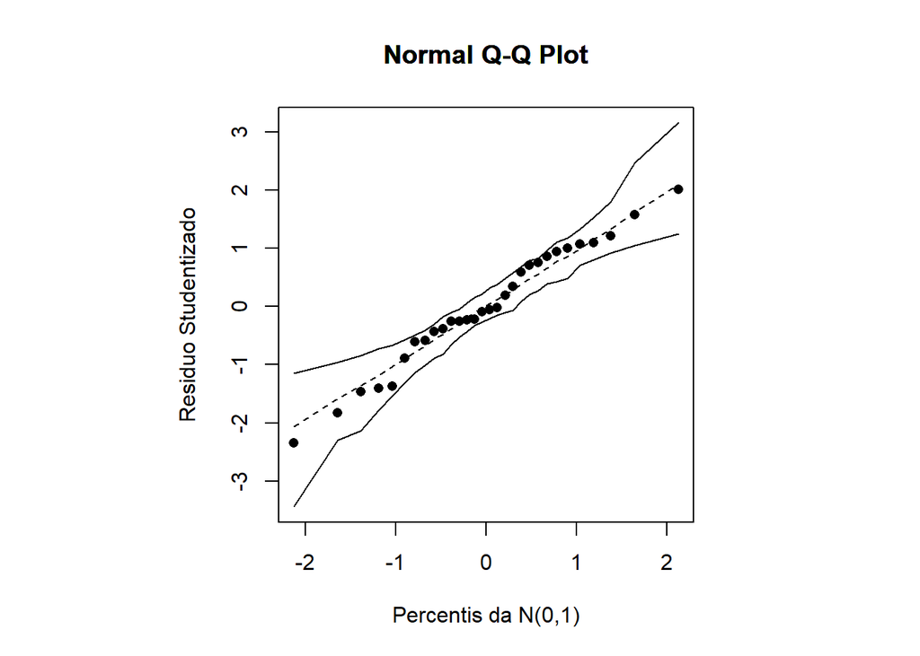

```
[1] "Normal-Link(log)"
```

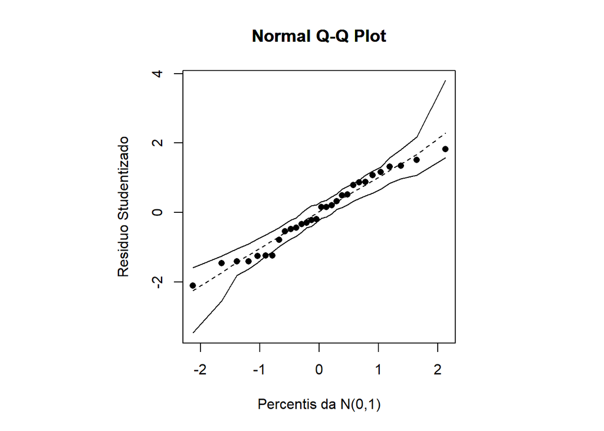

```
[1] "Normal-Link(inverse)"
```

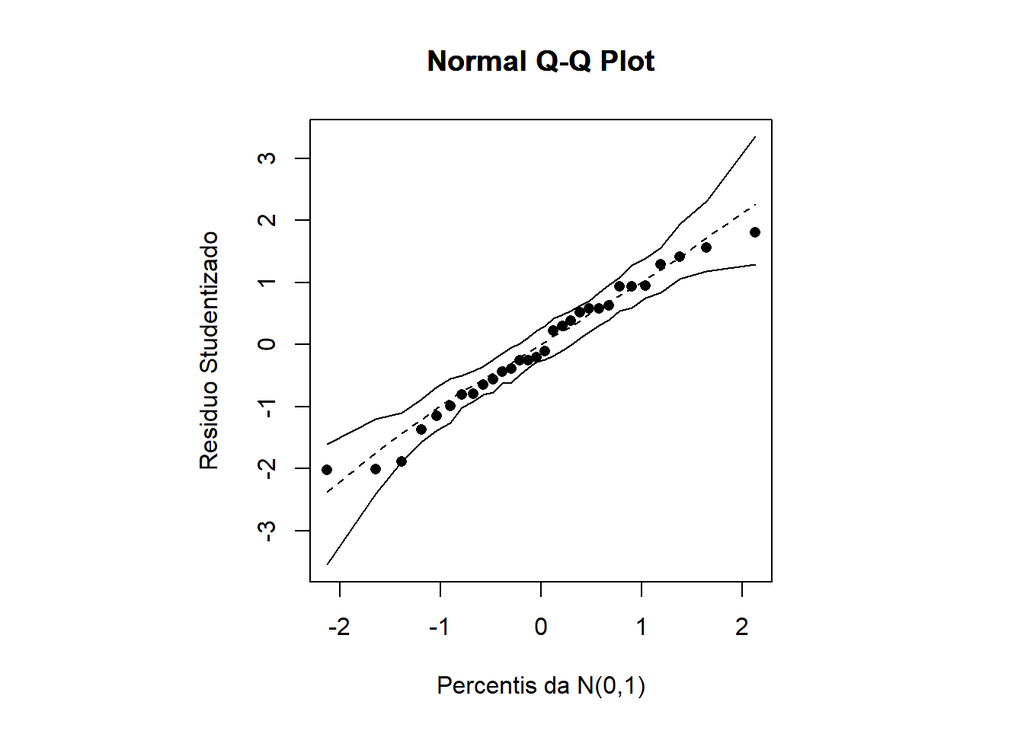

```r
modelo<-faturamento ~ gasto
normal<-rbind(
ResultadosNormal(restaurante, modelo, ligacao = "identity", tipo ="envel_norm"),
ResultadosNormal(restaurante, modelo, ligacao = "log", tipo ="envel_norm_log"),
ResultadosNormal(restaurante, modelo, ligacao = "inverse", tipo ="envel_norm_inverse"))
```

### Gama

**Código**

```
[1] "Gamma-Link(identity)"
```

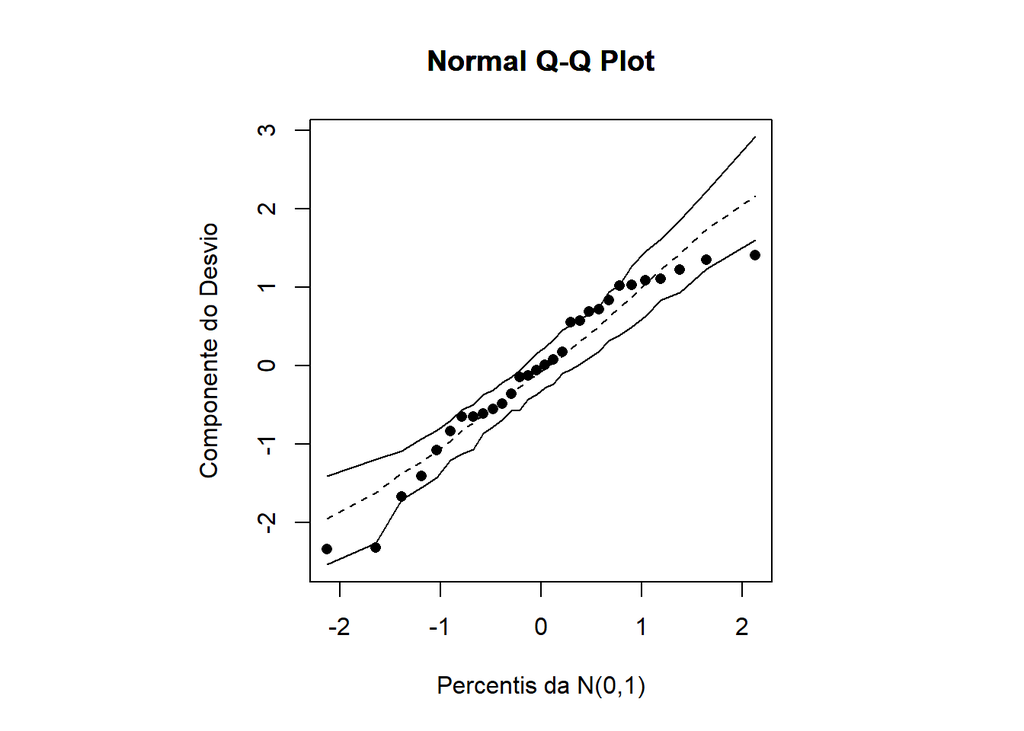

```
[1] "Gamma-Link(log)"
```

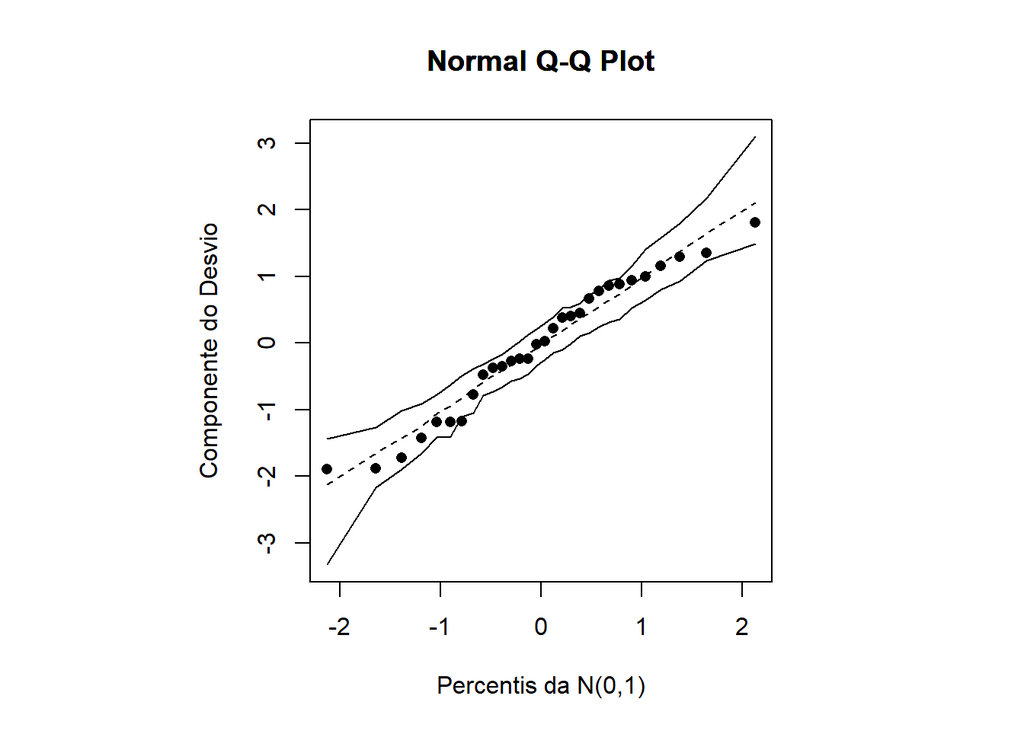

```
[1] "Gamma-Link(inverse)"
```

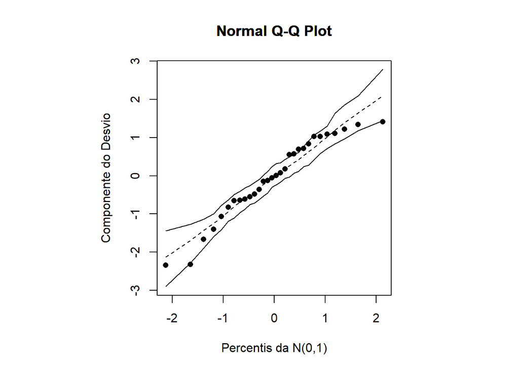

```r
gama<-rbind(
ResultadosGama(restaurante, modelo, ligacao = "identity", tipo ="envel_gama"),
ResultadosGama(restaurante, modelo, ligacao = "log", tipo ="envel_gama_log"),
ResultadosGama(restaurante, modelo, ligacao = "inverse", tipo ="envel_gama_inverse"))
```

### Normal Inversa

**Código**

```
[1] "Normal Inversa-Link(identity)"
```

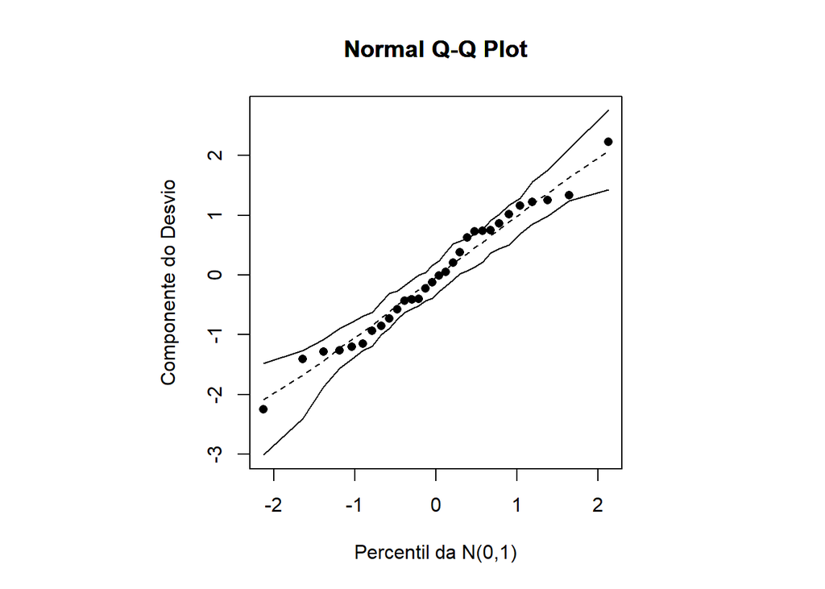

```
[1] "Normal Inversa-Link(log)"
```

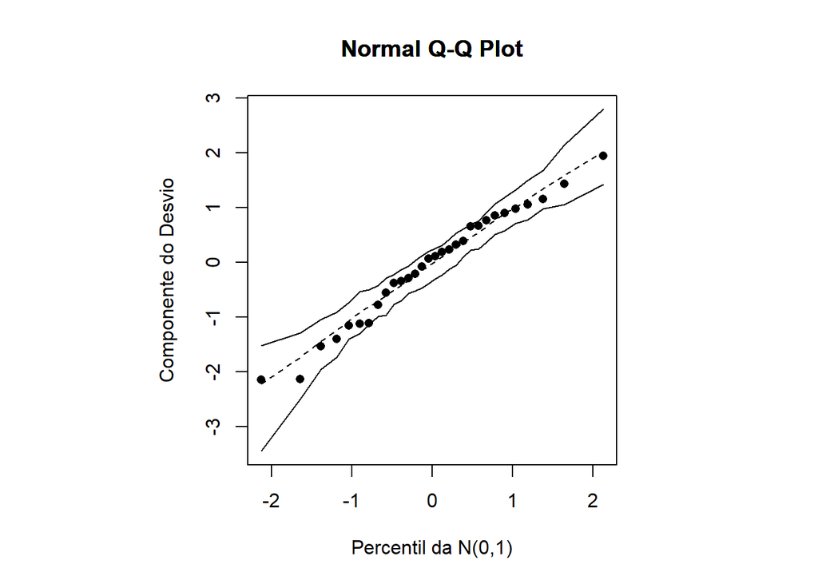

```
[1] "Normal Inversa-Link(inverse)"
```

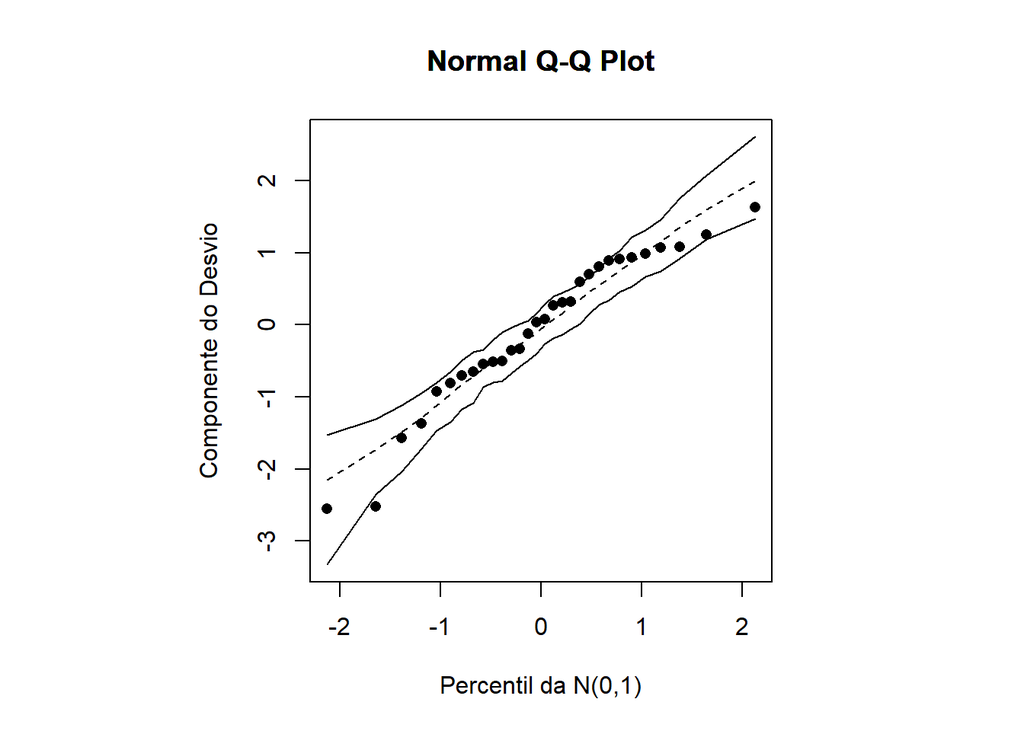

```
[1] "Normal Inversa-Link(inverse2)"
```

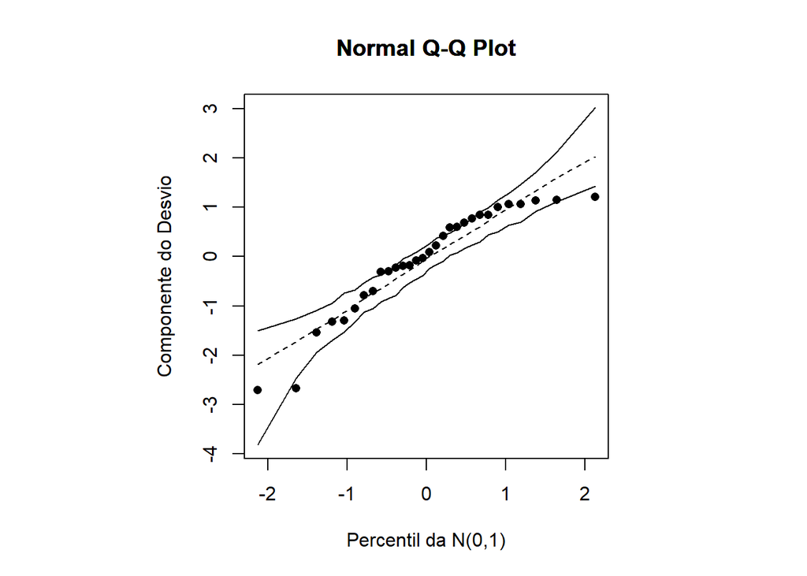

```r
NI<-rbind(
ResultadosNI(restaurante, modelo, ligacao = "identity", tipo ="envel_ninv"),
ResultadosNI(restaurante, modelo, ligacao = "log", tipo ="envel_ninv_log"),
ResultadosNI(restaurante, modelo, ligacao = "inverse", tipo ="envel_ninv_inverse"),
ResultadosNI(restaurante, modelo, ligacao = "inverse2", tipo ="envel_ninv_inverse2"))
```

**Código**

```r
selecaoModelo<-rbind(normal, gama, NI
)

selecaoModelo |>
  arrange(BIC) |>
  knitr::kable(caption = "Melhor modelo", format ="pipe")
```

Melhor modelo

| Family | QQplot | BIC | Modelo |
| --- | --- | --- | --- |
| Normal Inversa-Link(identity) | Ruim | 221.0796 | faturamento ~ gasto |
| Normal-Link(identity) | Ótimo | 225.0975 | faturamento ~ gasto |
| Gamma-Link(log) | Razoável | 229.5510 | faturamento ~ gasto |
| Normal-Link(log) | Razoável | 230.6393 | faturamento ~ gasto |
| Normal Inversa-Link(log) | Ótimo | 232.0443 | faturamento ~ gasto |
| Normal-Link(inverse) | Razoável | 246.2416 | faturamento ~ gasto |
| Gamma-Link(identity) | Ruim | 250.3646 | faturamento ~ gasto |
| Gamma-Link(inverse) | Ruim | 250.3646 | faturamento ~ gasto |
| Normal Inversa-Link(inverse) | Ruim | 254.4900 | faturamento ~ gasto |
| Normal Inversa-Link(inverse2) | Ruim | 271.3543 | faturamento ~ gasto |

## Teste de adequação da função de ligação

**Código**

```r
modelo<- faturamento ~ gasto
fit.model <- glm(modelo , family=inverse.gaussian(link=identity))
pl2 <- predict(fit.model)^2
fit.model2<-glm(update.formula(modelo,~ . + pl2), family=inverse.gaussian(link=identity))
testef(fit.model,fit.model2) # fit.model(H0: pl2 não significativa) #H1: pl2 é significativa
```

```
$f
[1] 0.3916767

$df1
[1] 1

$df2
[1] 27

$pvalue
[1] 0.5366744
```

A função de ligação identidade é adequada.

## Resíduos e Diagnóstico

**Código**

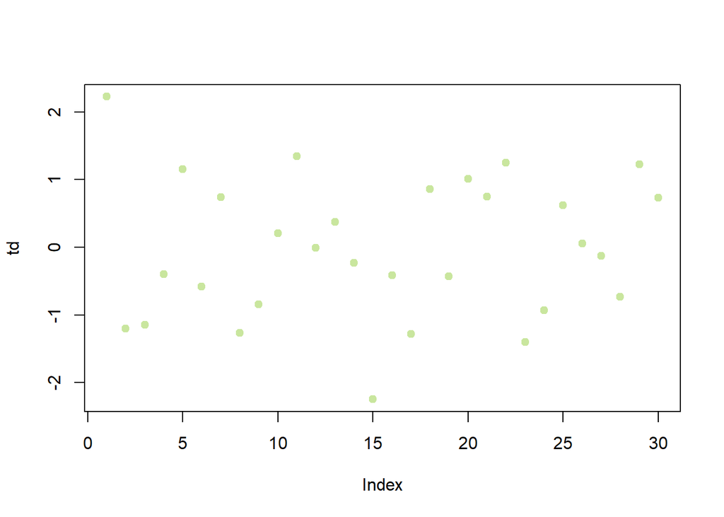

```r
modelo<-faturamento ~ gasto
fit.model<-glm(modelo,family=inverse.gaussian(link=identity))
X <- model.matrix(fit.model)
n <- nrow(X)
p <- ncol(X)
w <- fit.model$weights
V<-fitted(fit.model)
mu <-predict(fit.model,type="response")
W <- diag(w)
H <- solve(t(X)%*%W%*%X)
H <- sqrt(W)%*%X%*%H%*%t(X)%*%sqrt(W)
hii <- diag(H)
ro <- resid(fit.model,type="response")
fi <- (n-p)/sum((ro^2)/(fitted(fit.model)^3))
td <- resid(fit.model,type="deviance")*sqrt(fi/(1-hii))
# residuo deviance padronizado
rp1 <- resid(fit.model, type= "pearson")
rP <- as.numeric(sqrt(fi)*rp1)
tS <- rP/sqrt(V*(1 - hii))  # Residuo padronizado
plot(td,pch=19, col=cores[2])
```

**Código**

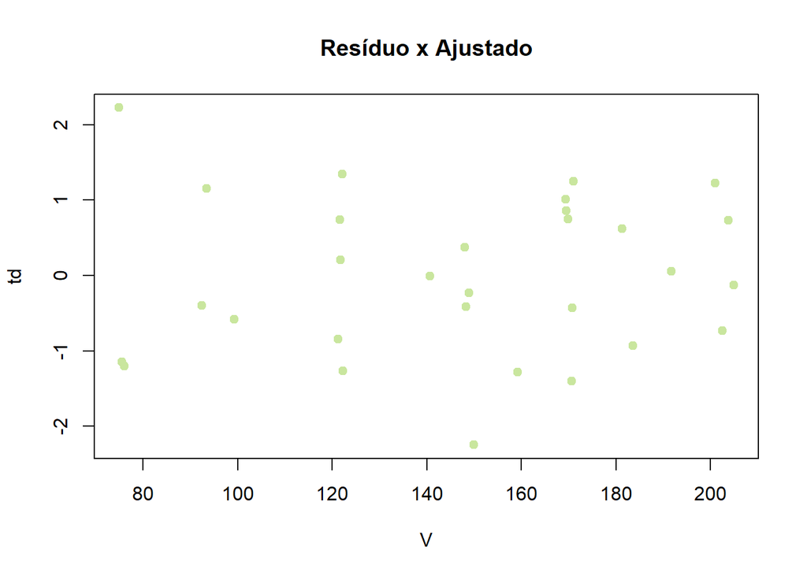

```r
plot(V,td, main="Resíduo x Ajustado", pch=19, col=cores[2])
```

**Código**

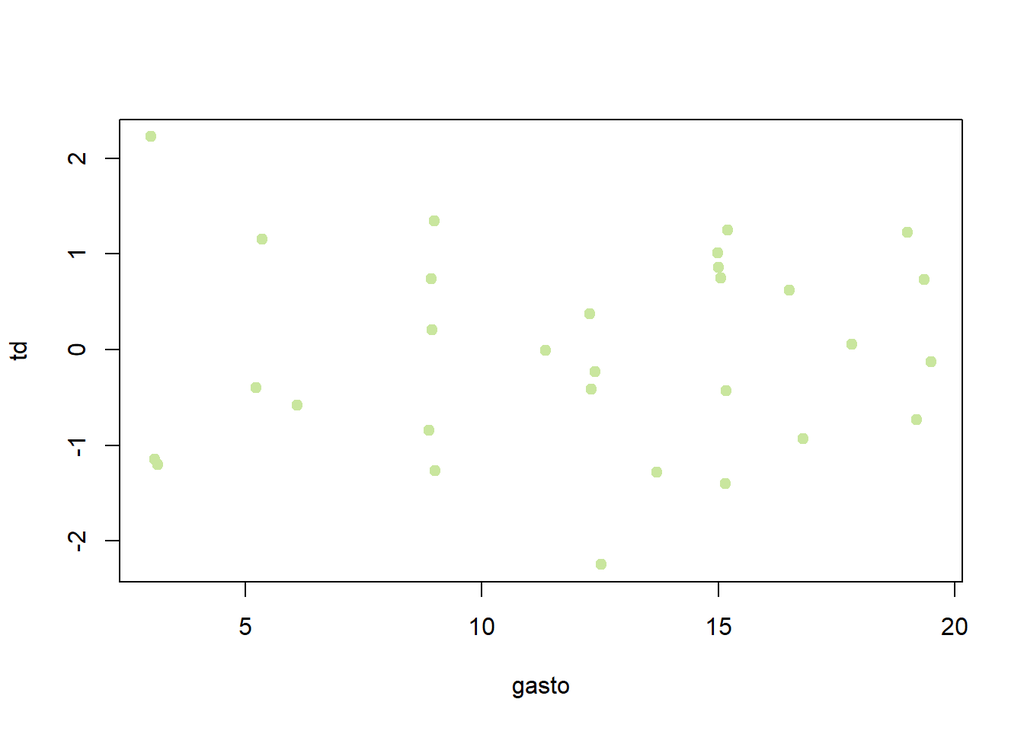

```r
plot(gasto, td,pch=19, col=cores[2] )
```

Não foram identificados nenhum padrão nos resíduos, o modelo foi validado.

#### Influência

**Código**

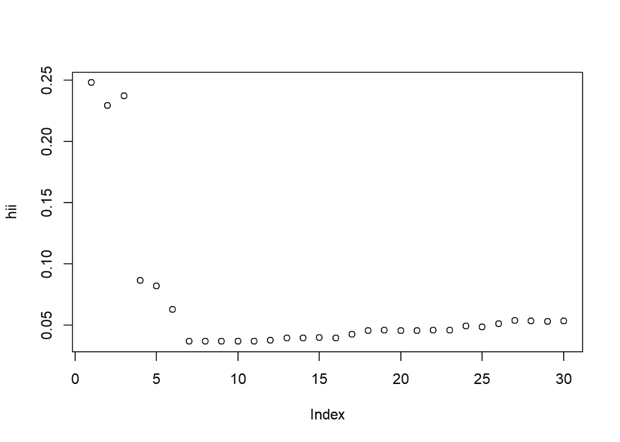

```r
plot(hii)
```

**Código**

```r
gasto[c(1,2,3)]
```

```
[1] 3.000 3.150 3.085
```

**Código**

```r
summary(gasto)
```

```
   Min. 1st Qu.  Median    Mean 3rd Qu.    Max.
  3.000   8.931  12.463  12.133  15.194  19.500
```

**Código**

```r
faturamento[c(1,2,3)]
```

```
[1] 81.464 72.661 72.344
```

**Código**

```r
summary(faturamento)
```

```
   Min. 1st Qu.  Median    Mean 3rd Qu.    Max.
  72.34  117.66  146.98  147.09  180.30  218.72
```

As observações com maiores alavancas são os restaurantes com os menores gastos com publicidade e com menores faturamentos.

**Código**

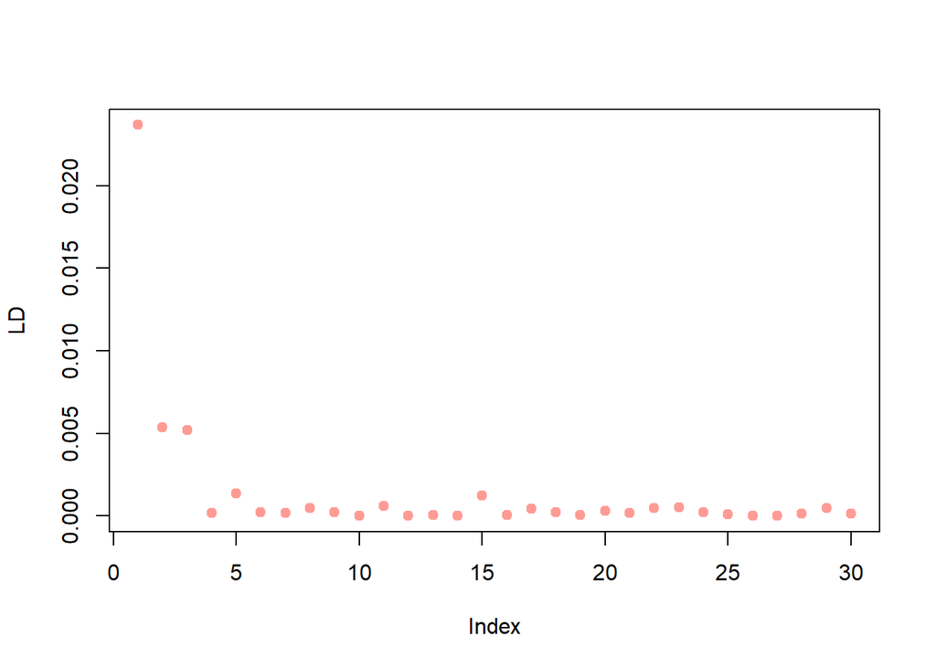

```r
LD = hii*(tS^2)/(1-hii)
plot(LD, pch=19, col=cores[4])
```

O restaurante 1 é o com maior influência na verossimilhança.

## Interpretação

**Código**

```r
fit.model$coefficients
```

```
(Intercept)       gasto
  51.280529    7.877416
```

- A cada mil dólares gastos com publicidade o faturamento aumenta em média 7.88 mil USD.

# Exercício 17

**Código**

```r
suppressMessages(dfilme <- read_table("dados/lista2/dfilme.txt",
    col_names = FALSE))
colnames(dfilme)<-c("tempo","densidade","condicao")
dfilme$condicao<-as.factor(dfilme$condicao)
```

## Análise Exploratória

**Código**

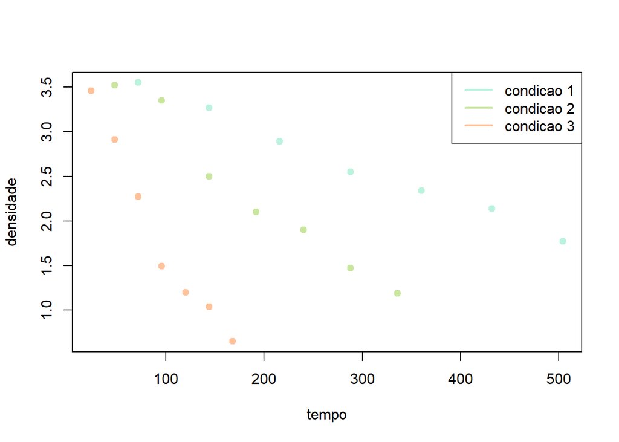

```r
suppressMessages(attach(dfilme))
plot(densidade~tempo, pch=19,col=cores[condicao])
legend("topright",lwd=2,legend = paste0("condicao ",1:3),col=cores[1:3])
```

**Código**

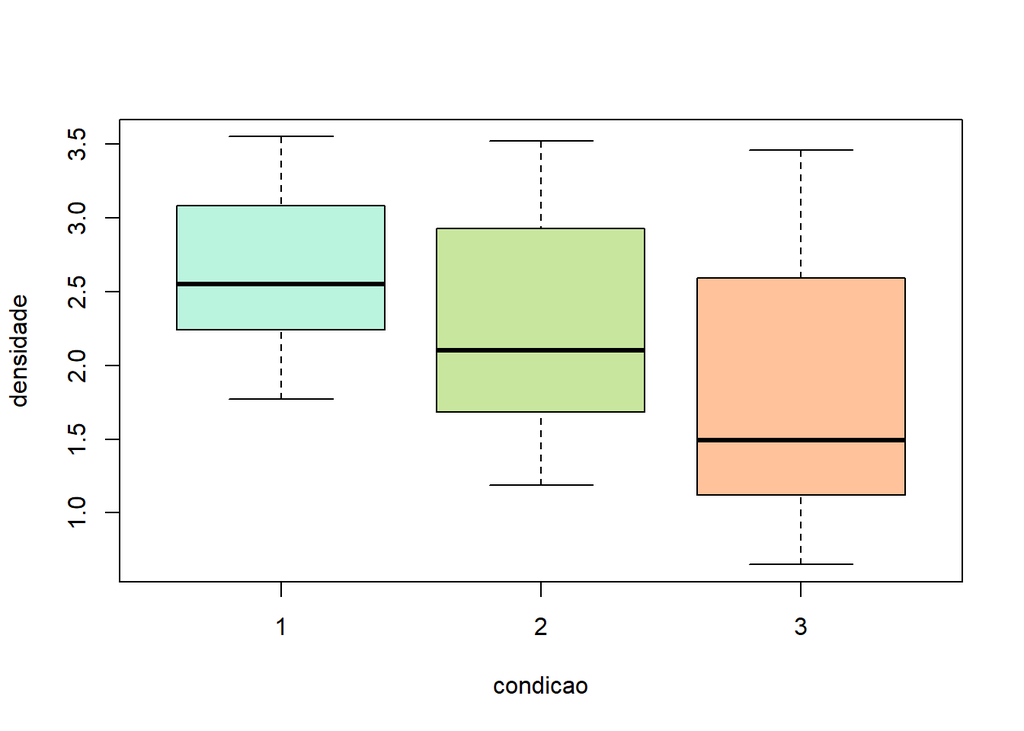

```r
boxplot(densidade~condicao, col=cores[1:3])
```

Na condição 1 a mediana da densidade máxima do filme é maior. A condição 3 parece ter uma maior variabilidade.

## Seleção do modelo

### Normal

**Código**

```
[1] "Normal-Link(identity)"
```

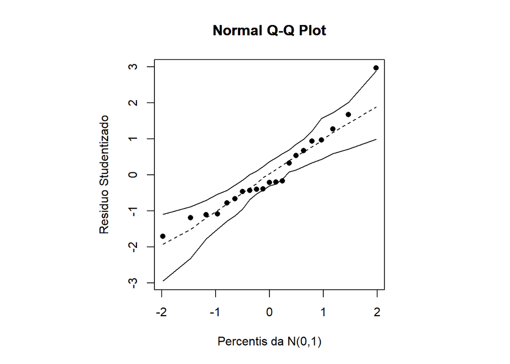

```
[1] "Normal-Link(log)"
[1] "Normal-Link(inverse)"
```

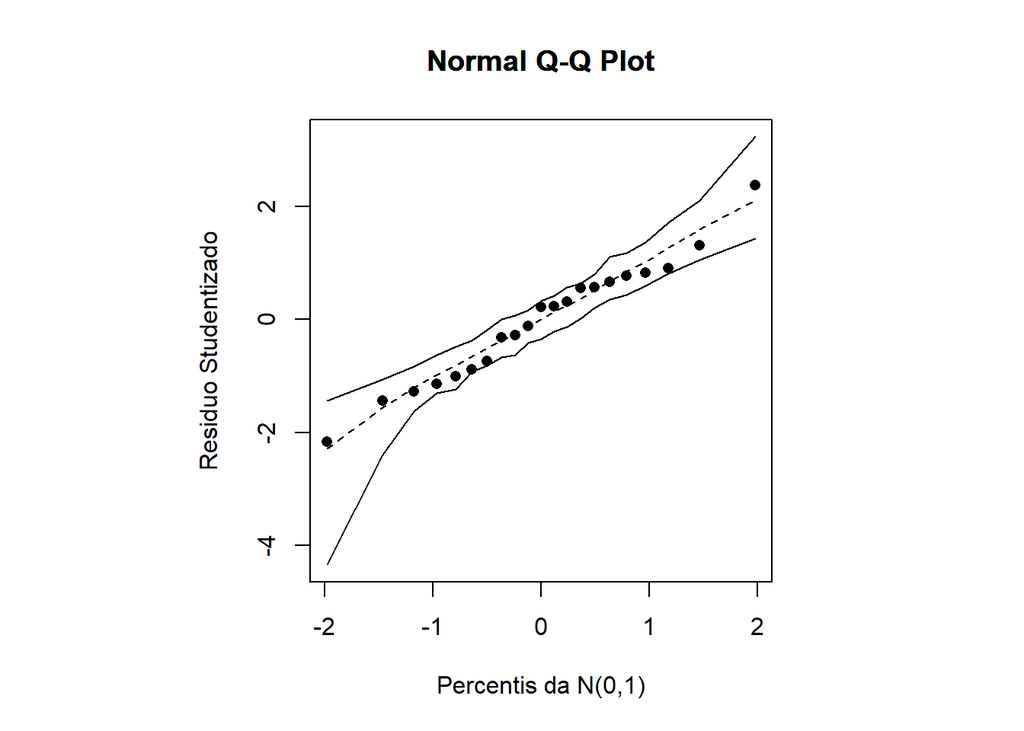

```r
modelo<-densidade ~ tempo + condicao
normal<-rbind(
ResultadosNormal(dfilme, modelo, ligacao = "identity", tipo ="envel_norm"),
ResultadosNormal(dfilme, modelo, ligacao = "log", tipo ="envel_norm_log"),
ResultadosNormal(dfilme, modelo, ligacao = "inverse", tipo ="envel_norm_inverse"))
```

### Gama

**Código**

```
[1] "Gamma-Link(identity)"
```

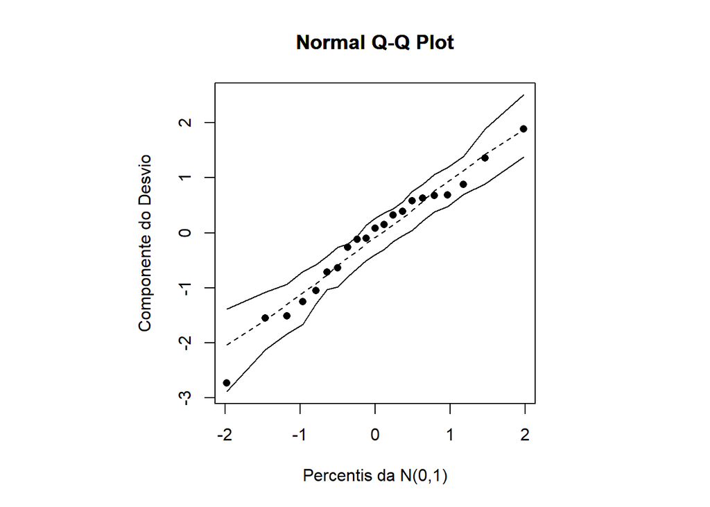

```
[1] "Gamma-Link(log)"
```

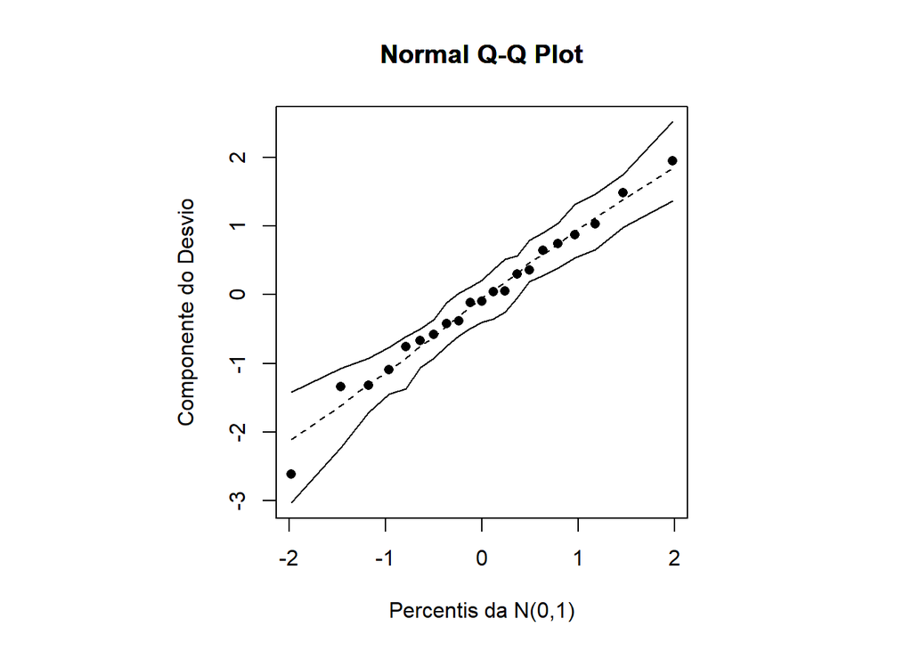

```
[1] "Gamma-Link(inverse)"
```

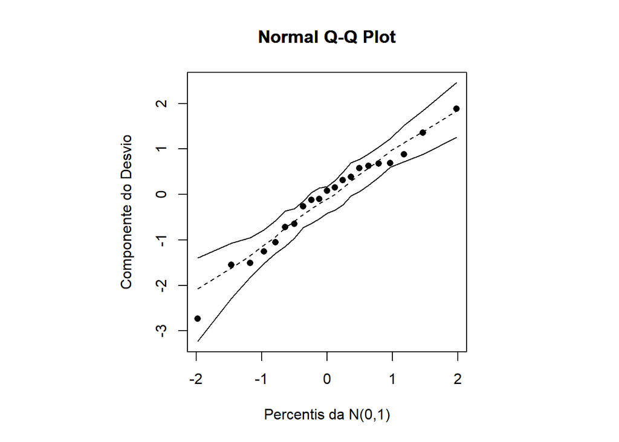

```r
gama<-rbind(
ResultadosGama(dfilme, modelo, ligacao = "identity", tipo ="envel_gama"),
ResultadosGama(dfilme, modelo, ligacao = "log", tipo ="envel_gama_log"),
ResultadosGama(dfilme, modelo, ligacao = "inverse", tipo ="envel_gama_inverse"))
```

### Normal Inversa

**Código**

```
[1] "Normal Inversa-Link(identity)"
```

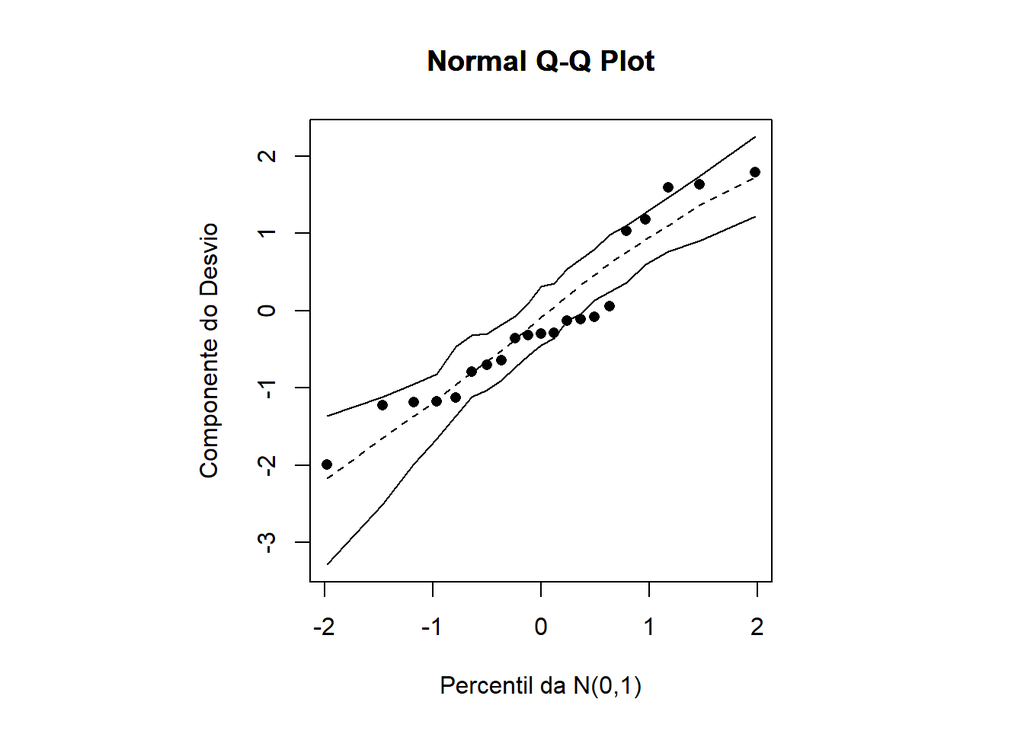

```
[1] "Normal Inversa-Link(log)"
```

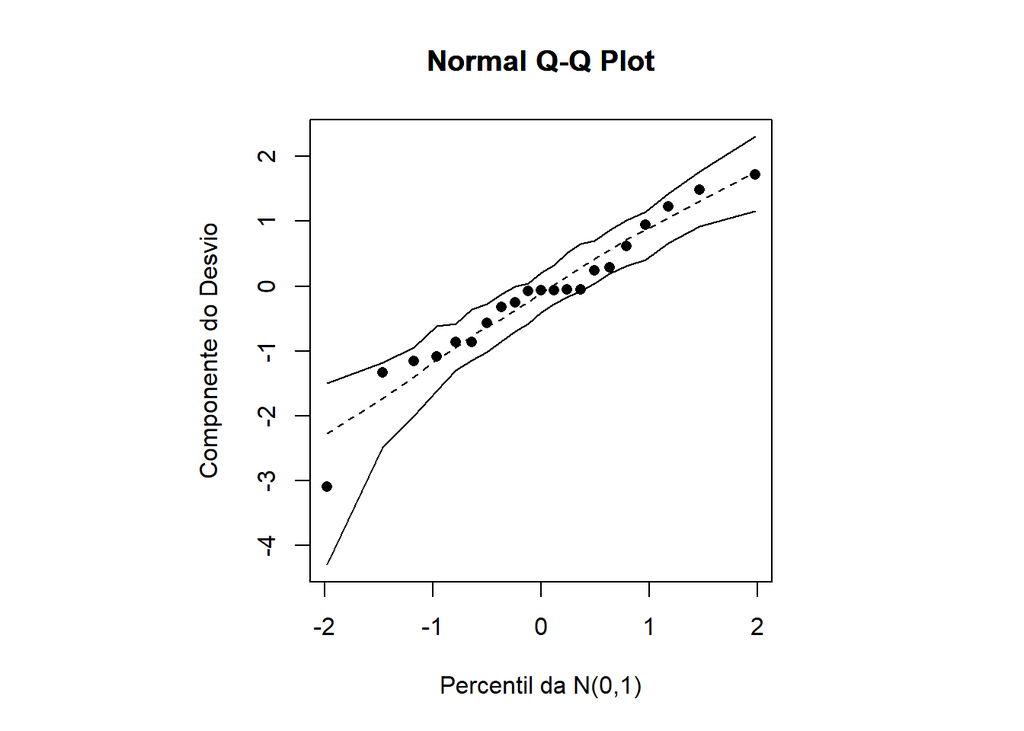

```
[1] "Normal Inversa-Link(inverse)"
```

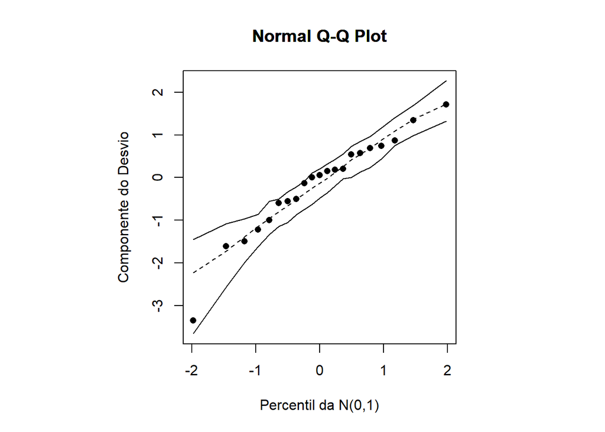

```
[1] "Normal Inversa-Link(inverse2)"
```

```r
NI<-rbind(
ResultadosNI(dfilme, modelo, ligacao = "identity", tipo ="envel_ninv"),
ResultadosNI(dfilme, modelo, ligacao = "log", tipo ="envel_ninv_log"),
ResultadosNI(dfilme, modelo, ligacao = "inverse", tipo ="envel_ninv_inverse"),
ResultadosNI(dfilme, modelo, ligacao = "inverse2", tipo ="envel_ninv_inverse2"))
```

**Código**

```r
selecaoModelo<-rbind(normal, gama, NI
)

selecaoModelo |>
  arrange(BIC) |>
  knitr::kable(caption = "Melhor modelo", format ="pipe")
```

Melhor modelo

| Family | QQplot | BIC | Modelo |
| --- | --- | --- | --- |
| Normal Inversa-Link(identity) | Ruim | 41.62497 | densidade ~ tempo + condicao |
| Normal-Link(identity) | Ruim | 41.89975 | densidade ~ tempo + condicao |
| Normal-Link(log) | Não Rodou | 45.81433 | densidade ~ tempo + condicao |
| Normal-Link(inverse) | Ótimo | 48.99714 | densidade ~ tempo + condicao |
| Gamma-Link(log) | Ótimo | 50.33303 | densidade ~ tempo + condicao |
| Normal Inversa-Link(log) | Ótimo | 54.26580 | densidade ~ tempo + condicao |
| Gamma-Link(identity) | Ótimo | 54.47345 | densidade ~ tempo + condicao |
| Gamma-Link(inverse) | Ótimo | 54.47345 | densidade ~ tempo + condicao |
| Normal Inversa-Link(inverse) | Ótimo | 59.59109 | densidade ~ tempo + condicao |
| Normal Inversa-Link(inverse2) | Não Rodou | 62.28059 | densidade ~ tempo + condicao |

O modelo selecionado foi o Normal com link “inverse”.

## Resíduos e Diagnóstico

**Código**

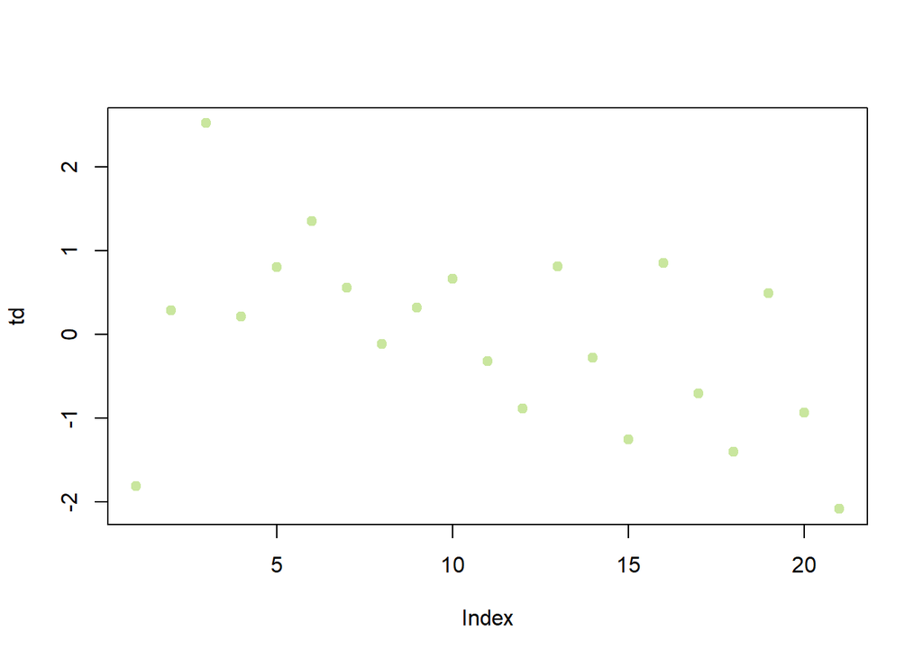

```r
modelo<-densidade ~ tempo + condicao
fit.model<-glm(modelo,family=gaussian(link=inverse))
X <- model.matrix(fit.model)
n <- nrow(X)
p <- ncol(X)
w <- fit.model$weights
fi <- (1/lm.influence(fit.model)$sigma)^2
V<-fitted(fit.model)
mu <-predict(fit.model,type="response")
W <- diag(w)
H <- solve(t(X)%*%W%*%X)
H <- sqrt(W)%*%X%*%H%*%t(X)%*%sqrt(W)
hii <- diag(H)
ro <- resid(fit.model,type="response")
td <- resid(fit.model,type="deviance")*sqrt(fi/(1-hii))

# residuo deviance padronizado
rp1 <- resid(fit.model, type= "pearson")
rP <- as.numeric(sqrt(fi)*rp1)
tS <- rP/sqrt(V*(1 - hii))  # Residuo padronizado
plot(td,pch=19, col=cores[2])
```

**Código**

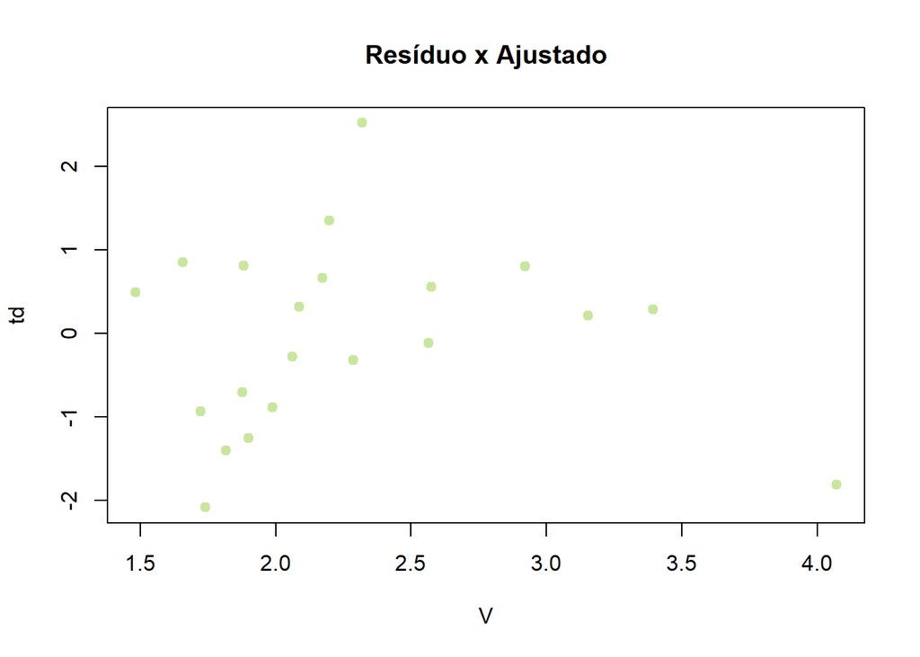

```r
plot(V,td, main="Resíduo x Ajustado", pch=19, col=cores[2])
```

**Código**

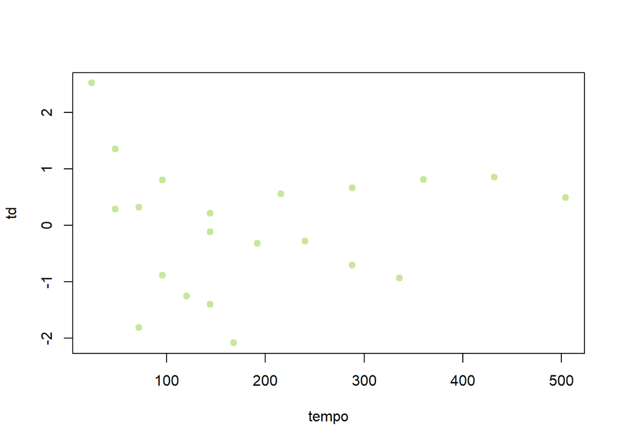

```r
plot(tempo, td,pch=19, col=cores[2])
```

Não parece haver padrões nos resíduos. Modelo validado.

## Teste de adequação da função de ligação

**Código**

```r
modelo<-densidade~ tempo + condicao
fit.model <- glm(modelo , family=gaussian(inverse))
pl2 <- predict(fit.model)^2
fit.model2<-glm(update.formula(modelo,~ . + pl2), family=gaussian(inverse))
testef(fit.model,fit.model2) # fit.model(H0: pl2 não significativa) #H1: pl2 é significativa
```

```
$f
[1] 5.20496

$df1
[1] 1

$df2
[1] 16

$pvalue
[1] 0.03655384
```

Temos evidências a 5% que a ligação não é adequada, mas considerando um nível de 1% a ligação pode ser considerada adequada. As evidências não são muito significativas para rejeitar a hipótese nula.

#### Influência

**Código**

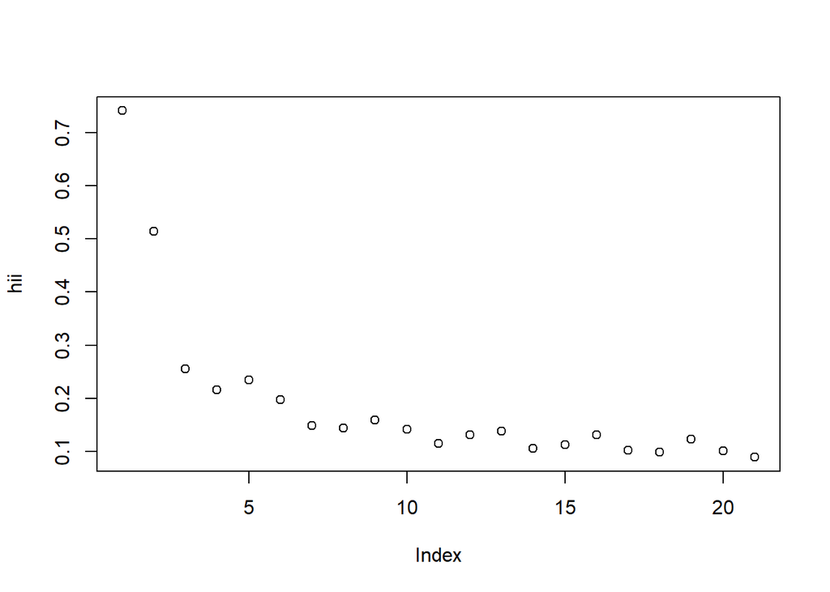

```r
plot(hii)
```

**Código**

```r
tempo[1]
```

```
[1] 72
```

**Código**

```r
summary(tempo)
```

```
   Min. 1st Qu.  Median    Mean 3rd Qu.    Max.
     24      96     144     192     288     504
```

**Código**

```r
densidade[1]
```

```
[1] 3.55
```

**Código**

```r
summary(densidade)
```

```
   Min. 1st Qu.  Median    Mean 3rd Qu.    Max.
  0.650   1.490   2.270   2.265   2.910   3.550
```

**Código**

```r
condicao[1]
```

```
[1] 1
Levels: 1 2 3
```

A observação com maior alavanca é a 1, ela possui o maior valor de densidade do filme.

**Código**

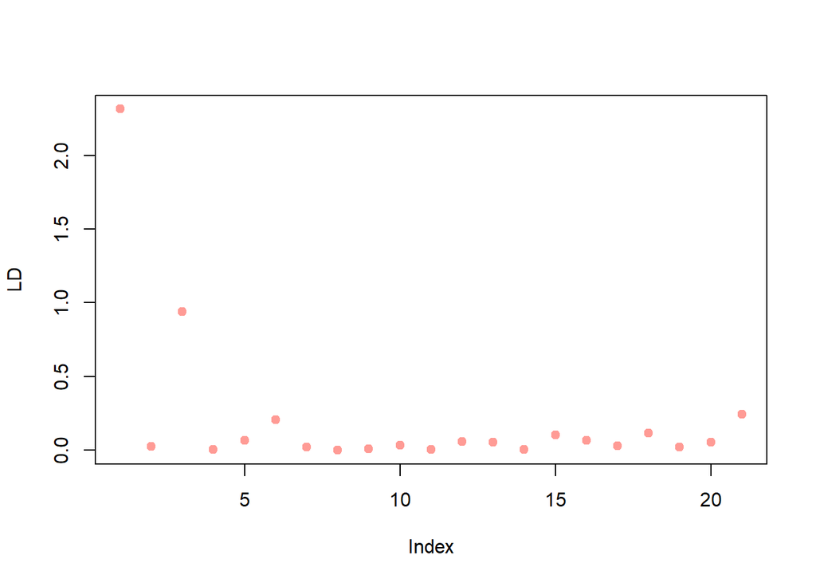

```r
LD = hii*(tS^2)/(1-hii)
plot(LD, pch=19, col=cores[4])
```

Além de ser alavanca a observação 1 influencia na verossimilhança.

# Exercício 19

**Código**

```r
suppressMessages(sobrev <- read_table("dados/lista2/sobrev.txt",
    col_names = FALSE))
colnames(sobrev)<-c("wbc","tempo", "ag")
sobrev$ag<-as.factor(sobrev$ag)
sobrev$wbc<-log(sobrev$wbc)
```

## Análise Exploratória

**Código**

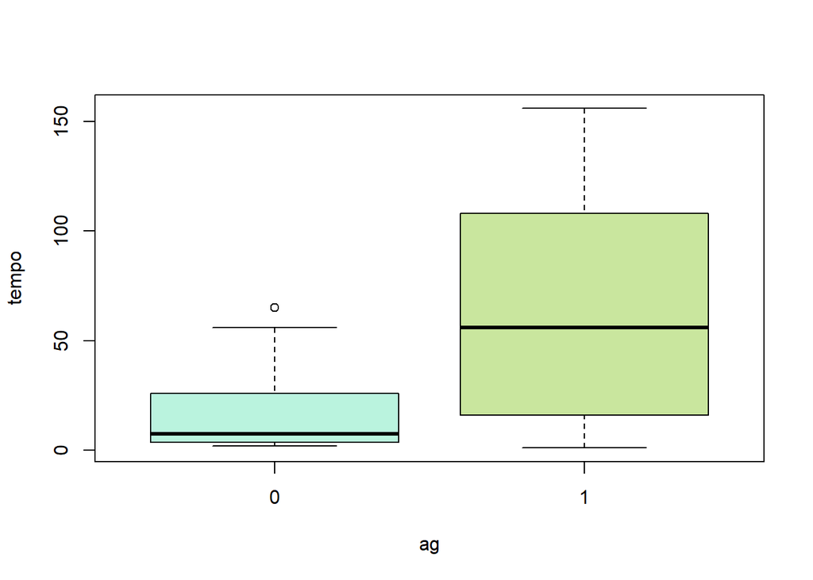

```r
suppressMessages(attach(sobrev))
boxplot(tempo~ag, col=cores)
```

O tempo de sobrevivência dos pacientes que apresentam a característica parece ser maior do que os que não possuiem tal característica.

**Código**

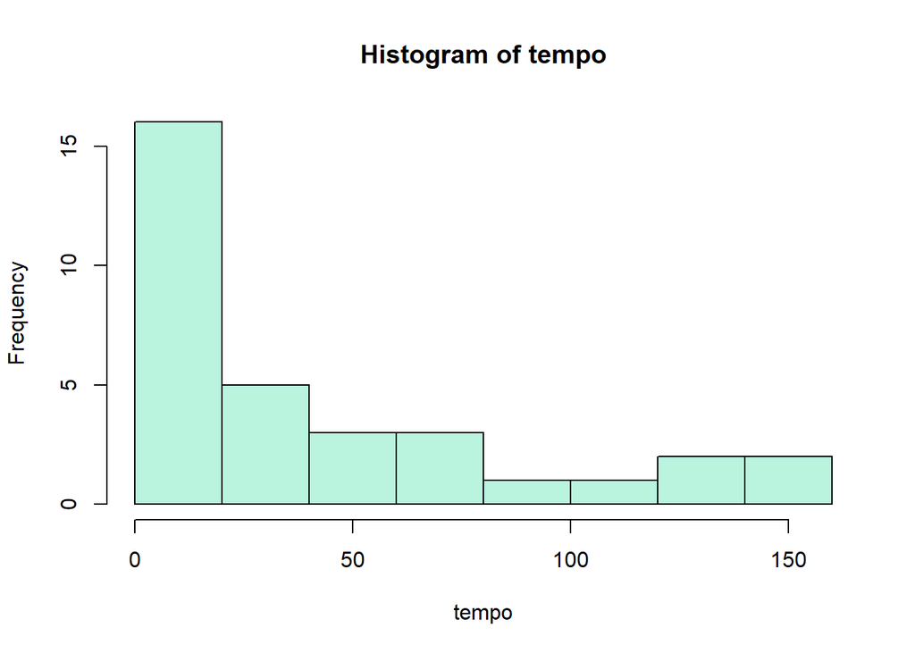

```r
hist(tempo, col=cores[1])
```

Bem assimétrico.

**Código**

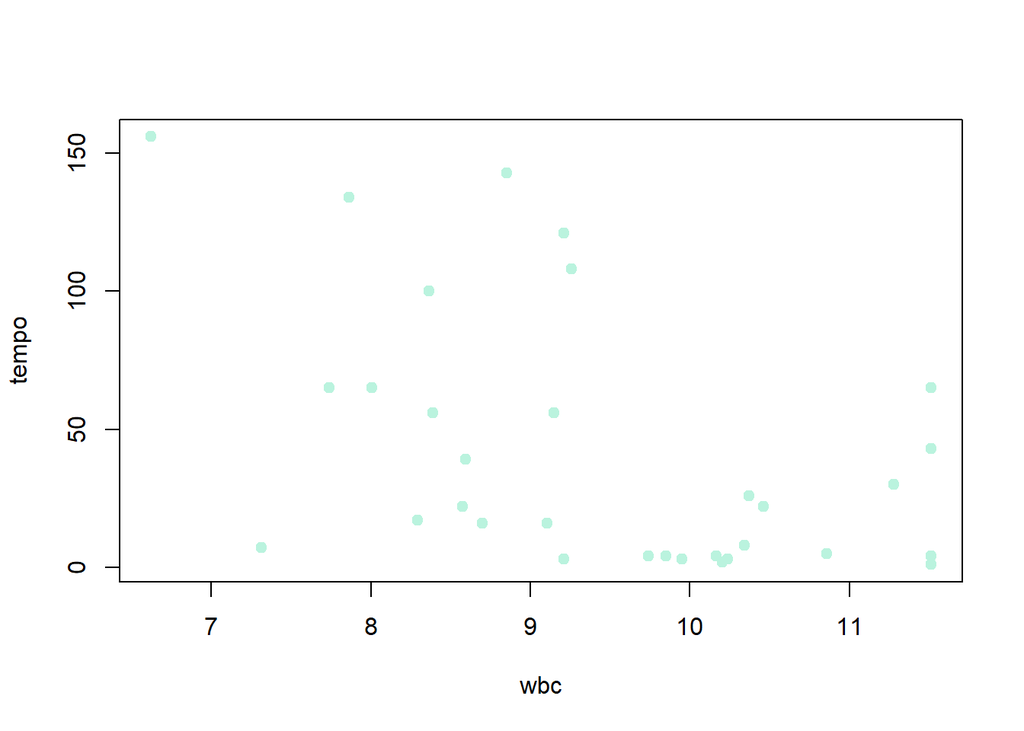

```r
plot(tempo~wbc, col=cores[1], pch=19)
```

## Seleção do modelo

### Normal

**Código**

```
[1] "Normal-Link(identity)"
```

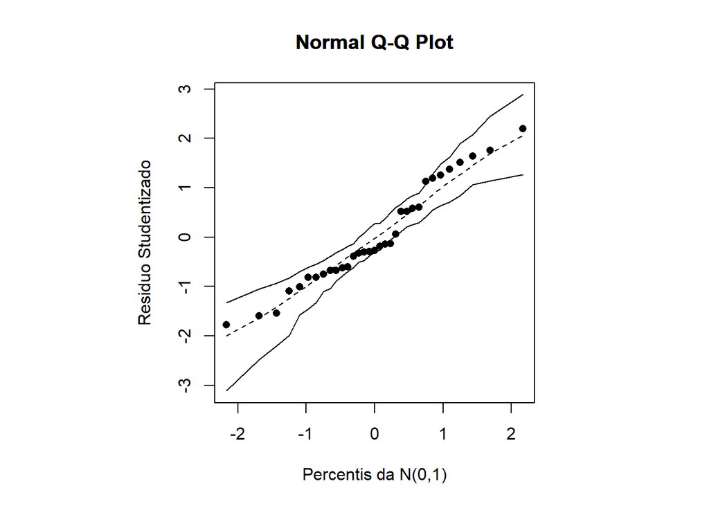

```
[1] "Normal-Link(log)"
[1] "Normal-Link(inverse)"
```

```r
modelo<-tempo ~ wbc + ag
normal<-rbind(
ResultadosNormal(sobrev, modelo, ligacao = "identity", tipo ="envel_norm"),
ResultadosNormal(sobrev, modelo, ligacao = "log", tipo ="envel_norm_log"),
ResultadosNormal(sobrev, modelo, ligacao = "inverse", tipo ="envel_norm_inverse"))
```

### Gama

**Código**

```
[1] "Gamma-Link(identity)"
```

```
[1] "Gamma-Link(log)"
```

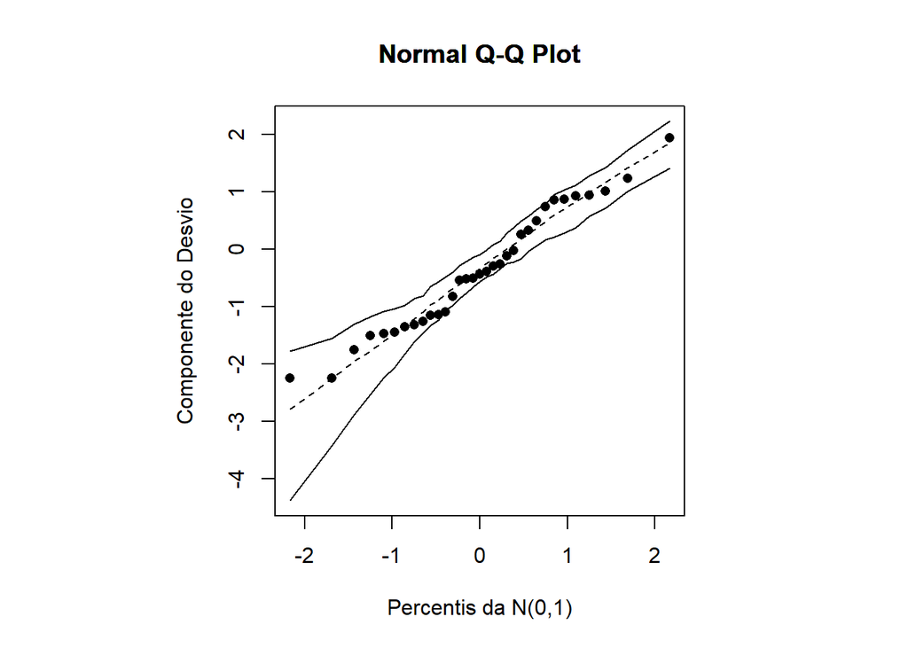

```
[1] "Gamma-Link(inverse)"
```

```r
gama<-rbind(
ResultadosGama(sobrev, modelo, ligacao = "identity", tipo ="envel_gama"),
ResultadosGama(sobrev, modelo, ligacao = "log", tipo ="envel_gama_log"),
ResultadosGama(sobrev, modelo, ligacao = "inverse", tipo ="envel_gama_inverse"))
```

### Normal Inversa

**Código**

```
[1] "Normal Inversa-Link(identity)"
```

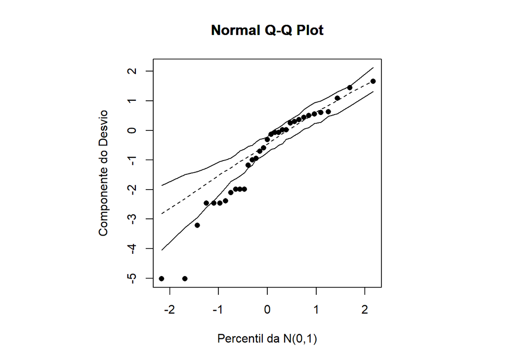

```
[1] "Normal Inversa-Link(log)"
```

```
[1] "Normal Inversa-Link(inverse)"
```

```
[1] "Normal Inversa-Link(inverse2)"
```

```r
NI<-rbind(
ResultadosNI(sobrev, modelo, ligacao = "identity", tipo ="envel_ninv"),
ResultadosNI(sobrev, modelo, ligacao = "log", tipo ="envel_ninv_log"),
ResultadosNI(sobrev, modelo, ligacao = "inverse", tipo ="envel_ninv_inverse"),
ResultadosNI(sobrev, modelo, ligacao = "inverse2", tipo ="envel_ninv_inverse2"))
```

**Código**

```r
selecaoModelo<-rbind(normal, gama, NI
)

selecaoModelo |>
  arrange(BIC) |>
  knitr::kable(caption = "Melhor modelo", format ="pipe")
```

Melhor modelo

| Family | QQplot | BIC | Modelo |
| --- | --- | --- | --- |
| Gamma-Link(identity) | Não Rodou | 307.205857 | tempo ~ wbc + ag |
| Gamma-Link(inverse) | Não Rodou | 307.205857 | tempo ~ wbc + ag |
| Gamma-Link(log) | Razoável | 307.473138 | tempo ~ wbc + ag |
| Normal Inversa-Link(identity) | Ruim | 317.257004 | tempo ~ ag |
| Normal Inversa-Link(inverse2) | Não Rodou | 320.06758 | tempo ~ wbc + ag |
| Normal-Link(log) | Não Rodou | 333.524647 | tempo ~ wbc + ag |
| Normal-Link(inverse) | Não Rodou | 336.162204 | tempo ~ wbc + ag |
| Normal-Link(identity) | Ruim | 339.979386 | tempo ~ wbc + ag |
| Normal Inversa-Link(log) | Não Rodou | Não Rodou | —– |
| Normal Inversa-Link(inverse) | Não Rodou | Não Rodou | —– |

## Teste de adequação da função de ligação

**Código**

```r
modelo<- tempo ~ wbc + ag
fit.model <- glm(modelo , family=Gamma(link=log))
pl2 <- predict(fit.model)^2
fit.model2<-glm(update.formula(modelo,~ . + pl2), family=Gamma(link=log))
testef(fit.model,fit.model2) # fit.model(H0: pl2 não significativa) #H1: pl2 é significativa
```

```
$f
[1] 1.843269

$df1
[1] 1

$df2
[1] 29

$pvalue
[1] 0.1850397
```

A ligação log é adequada para o modelo.

## Resíduos e Diagnóstico

**Código**

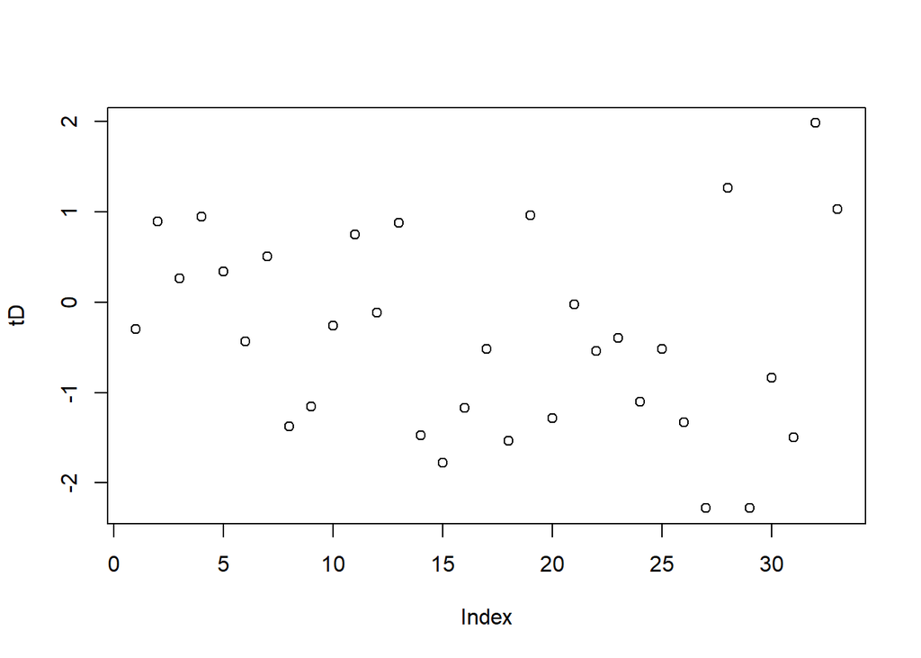

```r
modelo<- tempo ~ wbc + ag
fit.model <- glm(modelo , family=Gamma(link=log))
fi <- gamma.shape(fit.model)$alpha
X <- model.matrix(fit.model)
V <- fitted(fit.model)  # vetor de valores ajustados (model$fitted.values)
w <- fit.model$weights  # vetor de pesos
W <- diag(w)
H1 <- solve(t(X)%*%W%*%X)
H <- sqrt(W)%*%X%*%H1%*%t(X)%*%sqrt(W)
hii <- diag(H)  # vetor diagonal de H

# Residuos
rD <- resid(fit.model, type= "deviance")
tD <- rD*sqrt(fi/(1-hii))   # residuo deviance padronizado
rp1 <- resid(fit.model, type= "pearson")
rP <- as.numeric(sqrt(fi)*rp1)
tS <- rP/sqrt(V*(1 - hii))  # Residuo padronizado

plot(tD)
```

**Código**

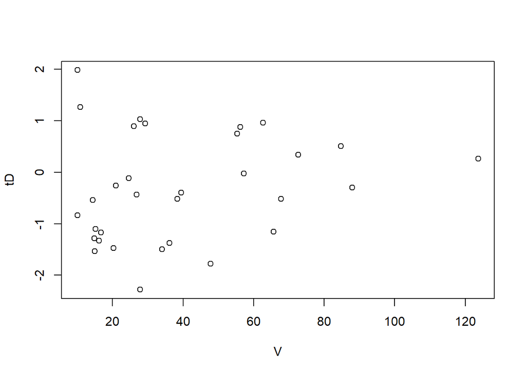

```r
plot(V,tD)
```

**Código**

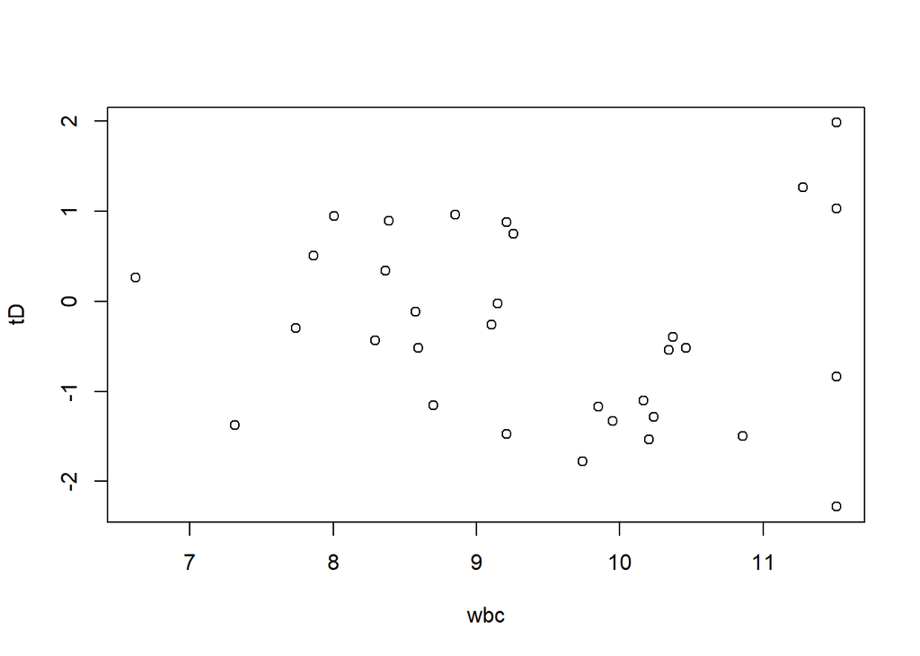

```r
plot(wbc,tD)
```

Não foi identificado nenhum padrão nos resíduos. O modelo foi validado.

#### Influência

**Código**

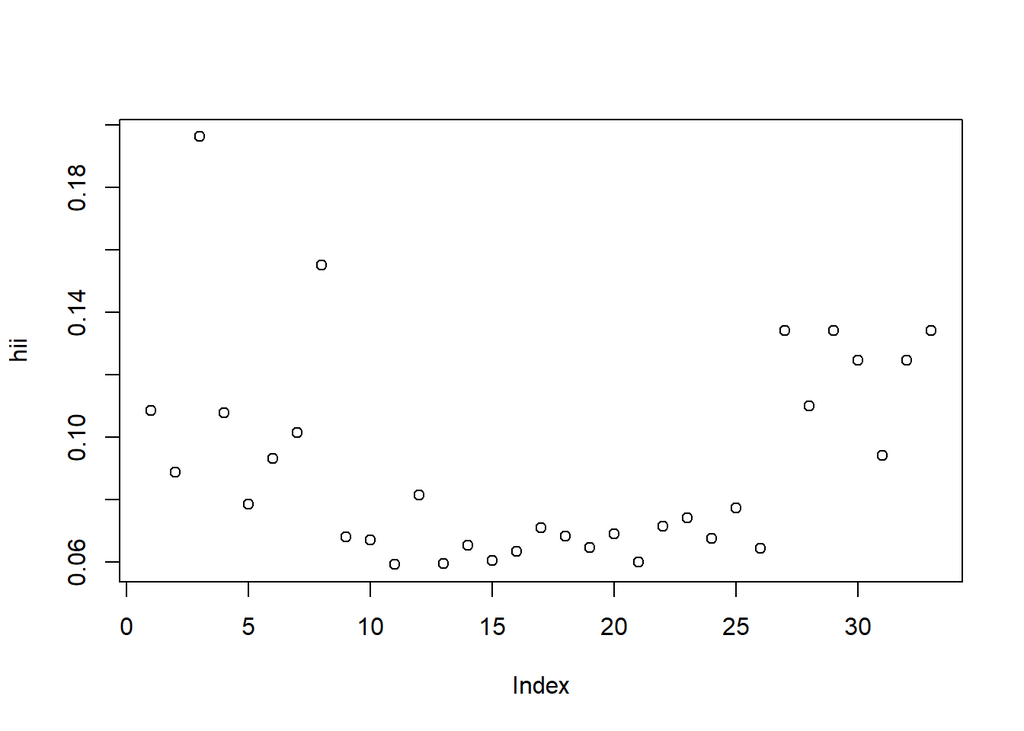

```r
plot(hii)
```

**Código**

```r
summary(tempo)
```

```
   Min. 1st Qu.  Median    Mean 3rd Qu.    Max.
   1.00    4.00   22.00   40.88   65.00  156.00
```

**Código**

```r
tempo[3]
```

```
[1] 156
```

**Código**

```r
summary(wbc)
```

```
   Min. 1st Qu.  Median    Mean 3rd Qu.    Max.
  6.620   8.575   9.259   9.524  10.373  11.513
```

**Código**

```r
wbc[3]
```

```
[1] 6.620073
```

**Código**

```r
ag[3]
```

```
[1] 1
Levels: 0 1
```

A observação 3 se refere ao paciente com maior tempo de sobrevivência após o dignóstico. Além disso, ele possui ag positivo para a característica.

**Código**

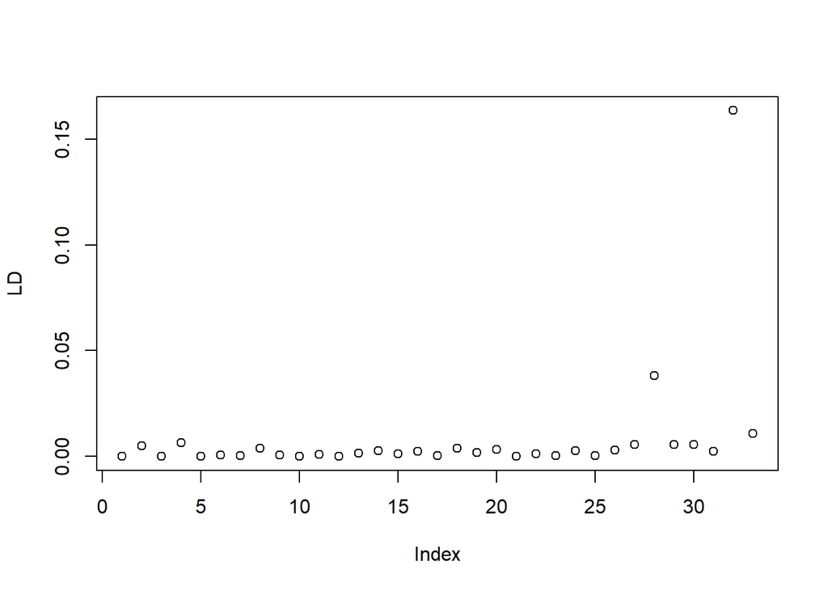

```r
LD = hii*(tS^2)/(1-hii)
plot(LD)
```

**Código**

```r
which(LD==max(LD))
```

```
32
32
```

**Código**

```r
tempo[32]
```

```
[1] 43
```

**Código**

```r
wbc[32]
```

```
[1] 11.51293
```

**Código**

```r
ag[32]
```

```
[1] 0
Levels: 0 1
```

**Código**

```r
summary(wbc)
```

```
   Min. 1st Qu.  Median    Mean 3rd Qu.    Max.
  6.620   8.575   9.259   9.524  10.373  11.513
```

Já a observação 32 se refere a um paciente sem a característica que possui o valor máximo de células brancas.

## Interpretação

**Código**

```r
exp(fit.model$coefficients)
```

```
(Intercept)         wbc         ag1
335.4291990   0.7375655   2.7666722
```

# Exercício 20

**Código**

```r
suppressMessages(claims <- read_table("dados/lista2/claims.txt",
    col_names = FALSE, col_types = cols(X10 = col_skip())))
colnames(claims)<-c("valorv","expos","nsinistros","csinistros",
                    "tipov","idadev","sexoc","areac","idadec")
cmsinistros<-as.numeric(claims$csinistros)/as.numeric(claims$nsinistros)

claims$tipov<-as.factor(claims$tipov)
claims$idadev<-as.factor(claims$idadev)
claims$sexoc<-as.factor(claims$sexoc)
claims$idadec<-as.factor(claims$idadec)
claims$areac<-as.factor(claims$areac)
```

## Análise Exploratória

**Código**

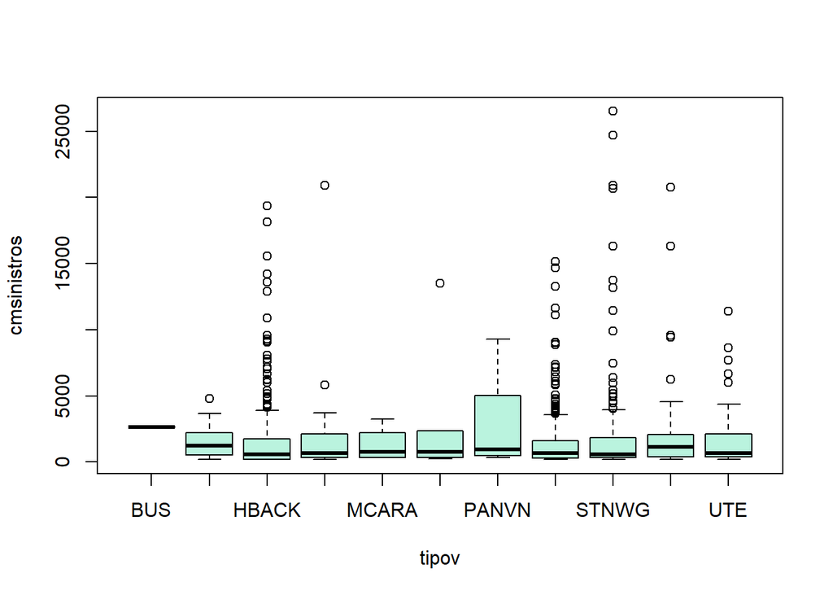

```r
suppressMessages(attach(claims))
boxplot(cmsinistros~tipov, col=cores[1])
```

**Código**

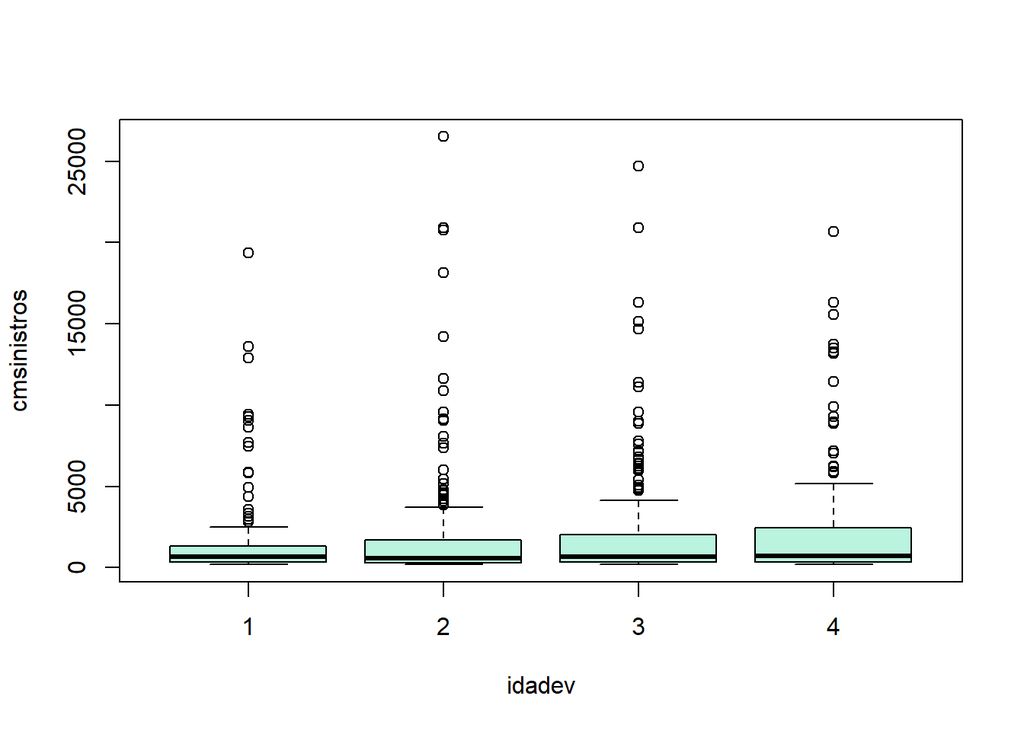

```r
boxplot(cmsinistros~idadev, col=cores[1])
```

**Código**

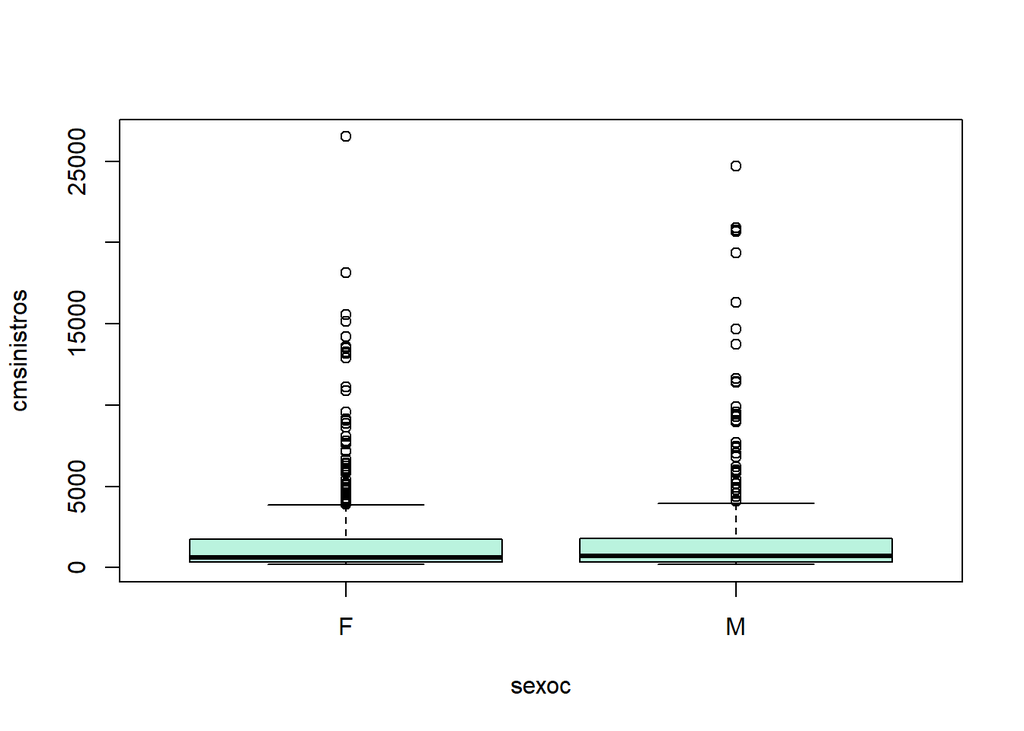

```r
boxplot(cmsinistros~sexoc, col=cores[1])
```

**Código**

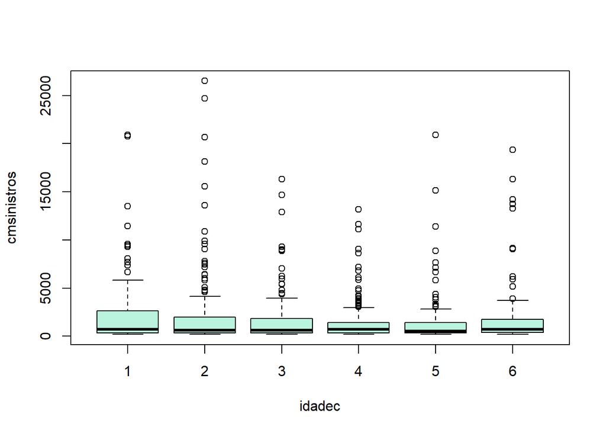

```r
boxplot(cmsinistros~idadec, col=cores[1])
```

**Código**

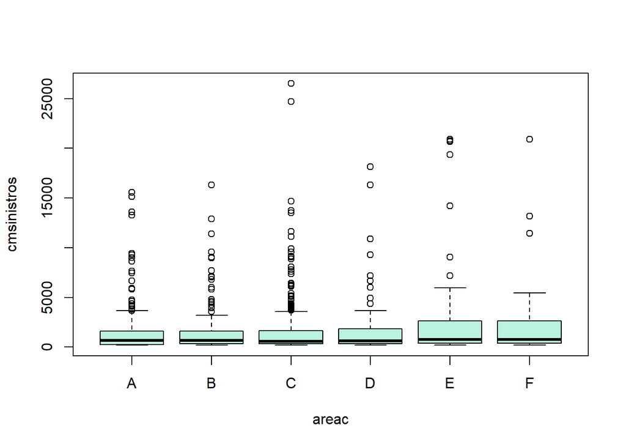

```r
boxplot(cmsinistros~areac, col=cores[1])
```

**Código**

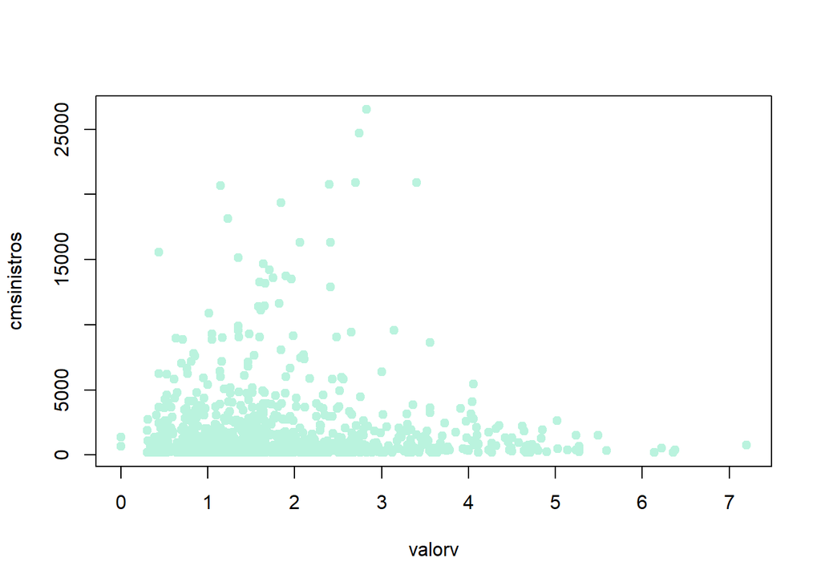

```r
plot(cmsinistros~valorv, col=cores[1],pch=19)
```

**Código**

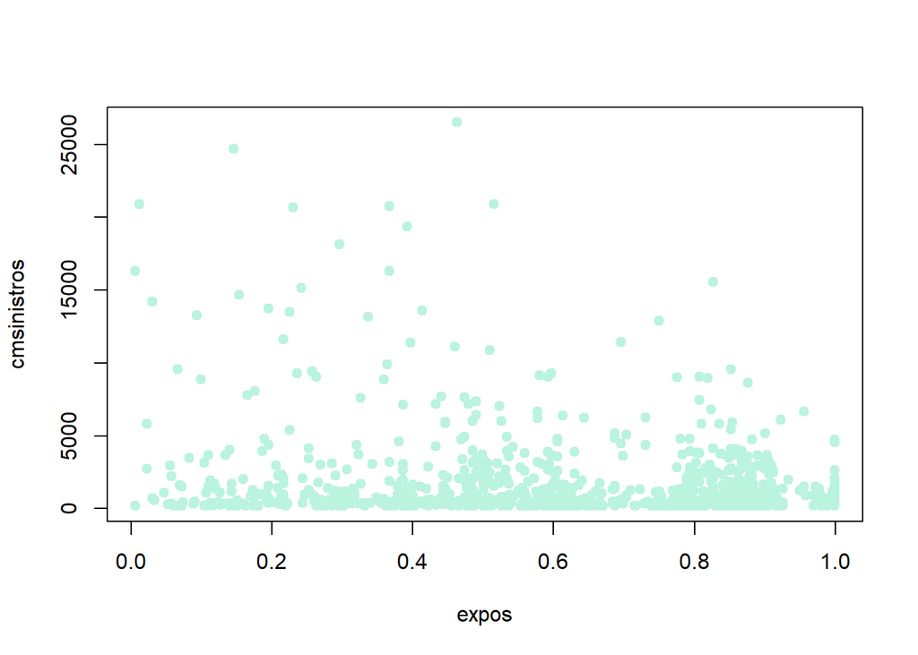

```r
plot(cmsinistros~expos, pch=19, col=cores[1])
```

**Código**

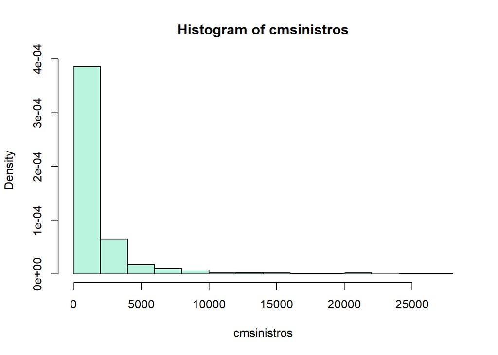

```r
hist(cmsinistros, col=cores[1], freq=F)
```

## Seleção do modelo

### Normal

**Código**

```
[1] "Normal-Link(identity)"
```

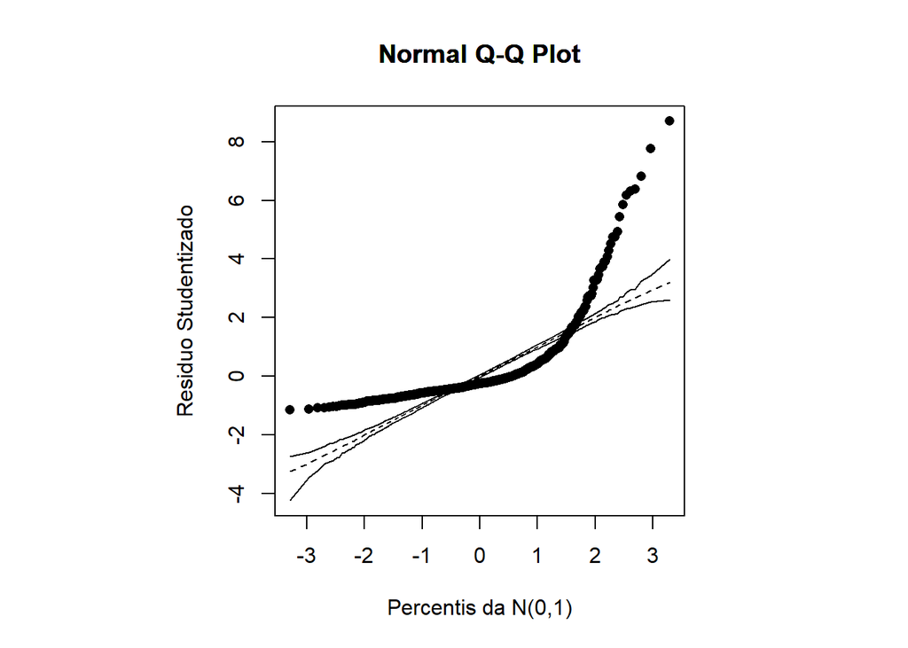

```
[1] "Normal-Link(log)"
[1] "Normal-Link(inverse)"
```

```r
modelo<-cmsinistros ~ valorv+expos+tipov+idadev+sexoc+areac+idadec

normal<-rbind(
ResultadosNormal(claims, modelo, ligacao = "identity", tipo ="envel_norm"),
ResultadosNormal(claims, modelo, ligacao = "log", tipo ="envel_norm_log"),
ResultadosNormal(claims, modelo, ligacao = "inverse", tipo ="envel_norm_inverse"))
```

### Gama

**Código**

```
[1] "Gamma-Link(identity)"
```

```
[1] "Gamma-Link(log)"
```

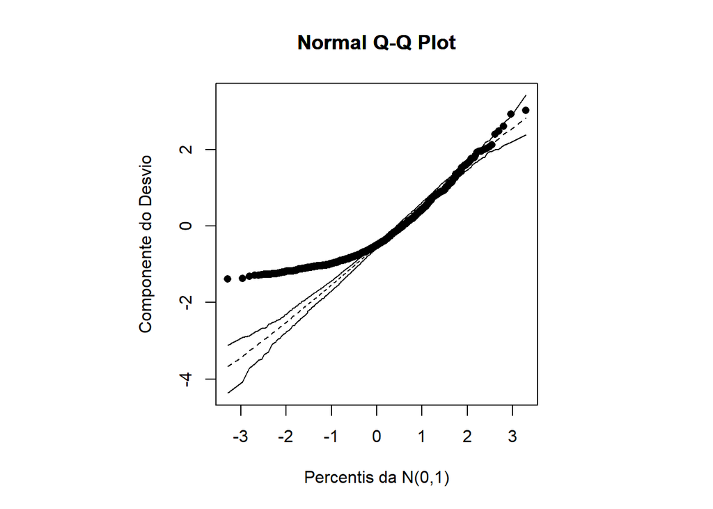

```
[1] "Gamma-Link(inverse)"
```

```r
gama<-rbind(
ResultadosGama(claims, modelo, ligacao = "identity", tipo ="envel_gama"),
ResultadosGama(claims, modelo, ligacao = "log", tipo ="envel_gama_log"),
ResultadosGama(claims, modelo, ligacao = "inverse", tipo ="envel_gama_inverse"))
```

### Normal Inversa

**Código**

```r
NI<-rbind(
ResultadosNI(claims, modelo, ligacao = "identity", tipo ="envel_ninv"),
ResultadosNI(claims, modelo, ligacao = "log", tipo ="envel_ninv_log"),
ResultadosNI(claims, modelo, ligacao = "inverse", tipo ="envel_ninv_inverse"),
ResultadosNI(claims, modelo, ligacao = "inverse2", tipo ="envel_ninv_inverse2"))
```

```
[1] "Normal Inversa-Link(identity)"
```

```
[1] "Normal Inversa-Link(log)"
```

```
[1] "Normal Inversa-Link(inverse)"
```

```
[1] "Normal Inversa-Link(inverse2)"
```

**Código**

```r
selecaoModelo<-rbind(normal, gama, NI
)

selecaoModelo |>
  arrange(BIC) |>
  knitr::kable(caption = "Melhor modelo", format ="pipe")
```

Melhor modelo

| Family | QQplot | BIC | Modelo |
| --- | --- | --- | --- |
| Gamma-Link(log) | Ruim | 16792.774902 | cmsinistros ~ valorv + expos + sexoc + idadec |
| Normal-Link(inverse) | Não Rodou | 18705.364725 | cmsinistros ~ expos + tipov + idadev + areac + idadec |
| Normal-Link(identity) | Ruim | 18749.407009 | cmsinistros ~ expos + idadec |
| Normal-Link(log) | Não Rodou | 18812.634946 | cmsinistros ~ expos + tipov + idadev + sexoc + areac + idadec |
| Gamma-Link(identity) | Não Rodou | Não Rodou | —– |
| Gamma-Link(inverse) | Não Rodou | Não Rodou | —– |
| Normal Inversa-Link(identity) | Não Rodou | Não Rodou | —– |
| Normal Inversa-Link(log) | Não Rodou | Não Rodou | —– |
| Normal Inversa-Link(inverse) | Não Rodou | Não Rodou | —– |
| Normal Inversa-Link(inverse2) | Não Rodou | Não Rodou | —– |

O modelo selecionado foi o Gamma-Link(log) cmsinistros ~ valorv + expos + sexoc + idadec

## Teste de adequação da função de ligação

**Código**

```r
modelo<- cmsinistros ~ valorv + expos + sexoc + idadec
fit.model <- glm(modelo , family=Gamma(link=log))
pl2 <- predict(fit.model)^2
fit.model2<-glm(update.formula(modelo,~ . + pl2), family=Gamma(link=log))
testef(fit.model,fit.model2) # fit.model(H0: pl2 não significativa) #H1: pl2 é significativa
```

```
$f
[1] 6.673961

$df1
[1] 1

$df2
[1] 986

$pvalue
[1] 0.009926132
```

A função de ligação log não é apropriada.

## Teste de adequação da função de ligação

**Código**

```r
modelo<- cmsinistros ~ expos + idadec
fit.model <- glm(modelo , family=gaussian())
pl2 <- predict(fit.model)^2
fit.model2<-glm(update.formula(modelo,~ . + pl2), family=gaussian())
testef(fit.model,fit.model2) # fit.model(H0: pl2 não significativa) #H1: pl2 é significativa
```

```
$f
[1] 15.75598

$df1
[1] 1

$df2
[1] 988

$pvalue
[1] 7.727713e-05
```

A normal com link identidade também não foi adequada.

## Resíduos e Diagnóstico

**Código**

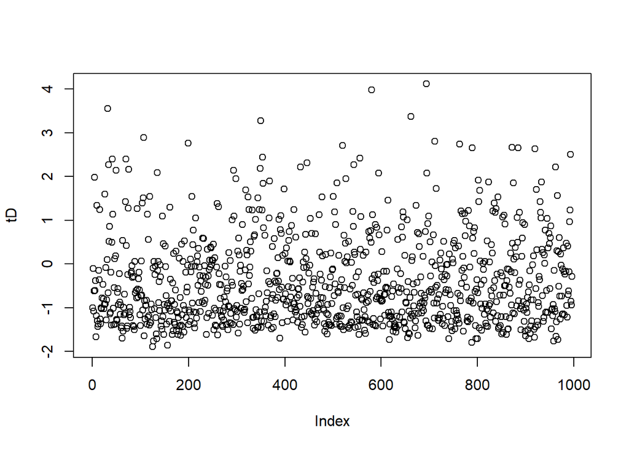

```r
modelo<- cmsinistros ~ valorv + expos + sexoc + idadec
fit.model <- glm(modelo , family=Gamma(link=log))
fi <- gamma.shape(fit.model)$alpha
X <- model.matrix(fit.model)
V <- fitted(fit.model)  # vetor de valores ajustados (model$fitted.values)
w <- fit.model$weights  # vetor de pesos
W <- diag(w)
H1 <- solve(t(X)%*%W%*%X)
H <- sqrt(W)%*%X%*%H1%*%t(X)%*%sqrt(W)
hii <- diag(H)  # vetor diagonal de H

# Residuos
rD <- resid(fit.model, type= "deviance")
tD <- rD*sqrt(fi/(1-hii))   # residuo deviance padronizado
rp1 <- resid(fit.model, type= "pearson")
rP <- as.numeric(sqrt(fi)*rp1)
tS <- rP/sqrt(V*(1 - hii))  # Residuo padronizado

plot(tD)
```

**Código**

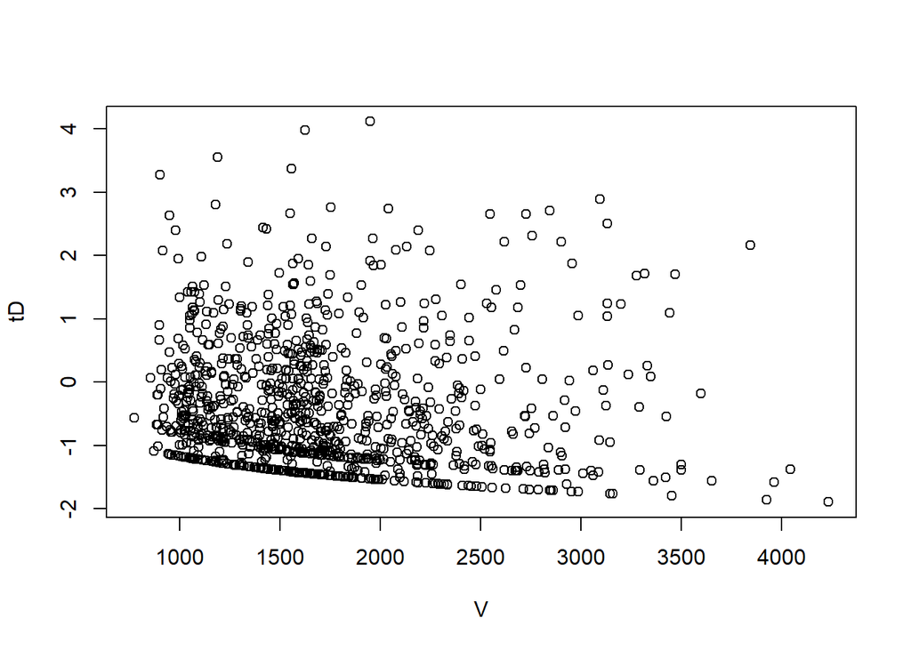

```r
plot(V,tD)
```

**Código**

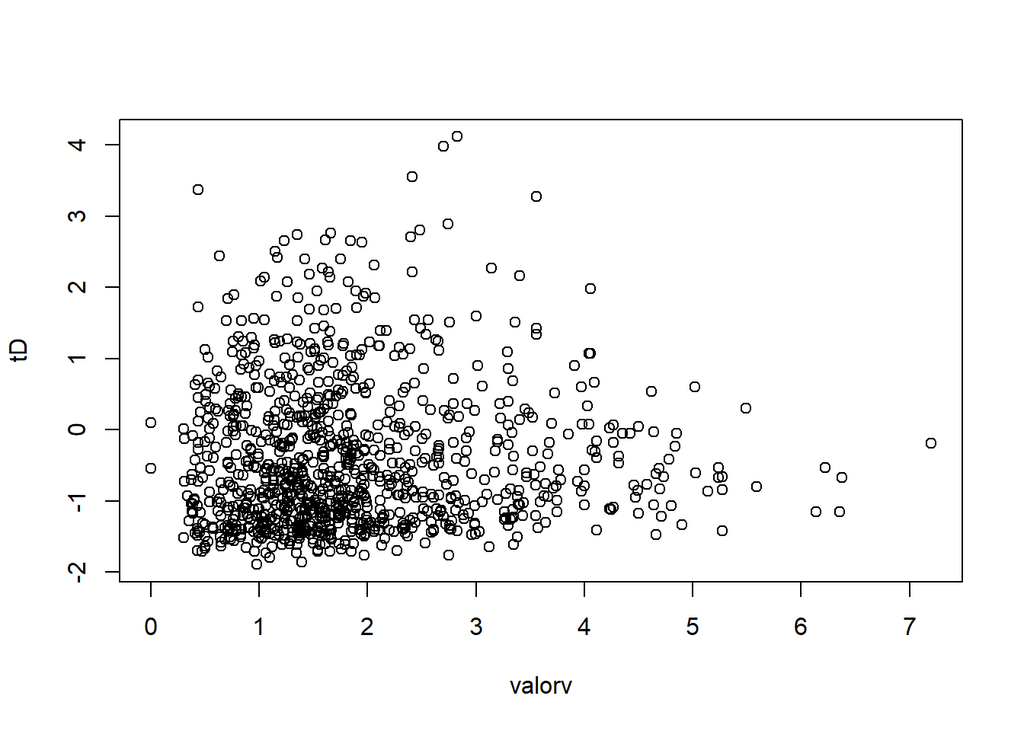

```r
plot(valorv,tD)
```

**Código**

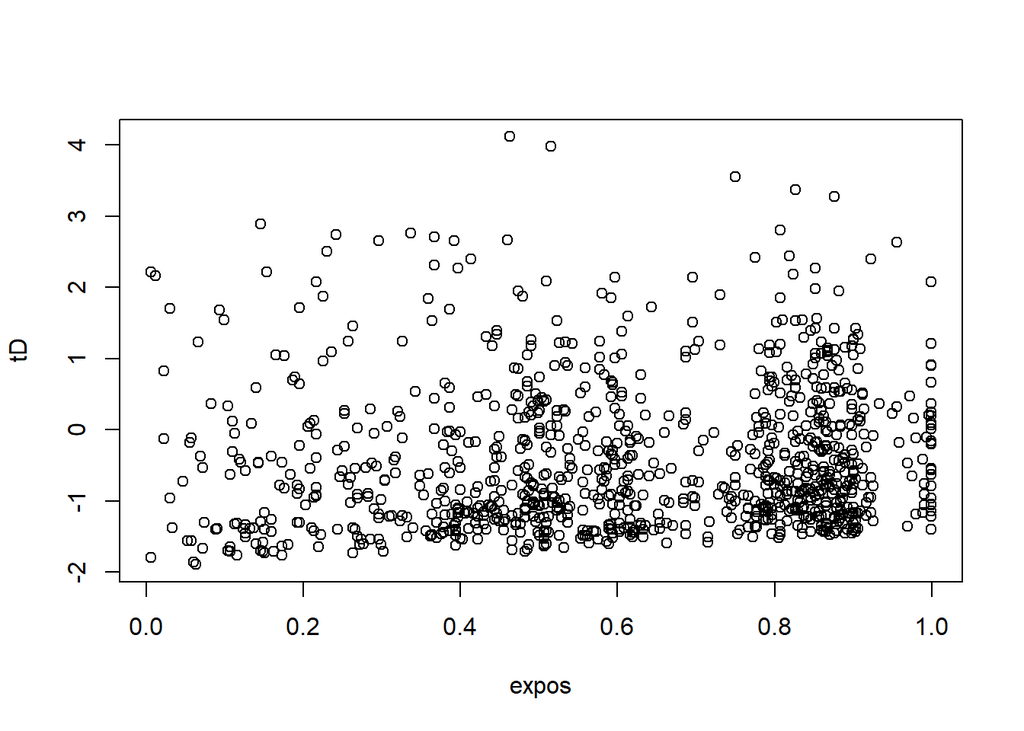

```r
plot(expos,tD)
```

Não foi obtido um modelo validado. Os que rodaram não tiveram a ligação adequada.

# Classificação dos envelopes

- **Ótimo:** O qqplot é classificado como ótimo se a proporção de pontos fora das bandas for igual a zero.
- **Bom:** A proporção de pontos fora é maior que zero e menor que alfa/2(alfa=0.05, nesse trabalho).
- **Razoável:** A proporção é maior que alfa/2 e menor que alfa.
- **Ruim:** A proporção de pontos fora das bandas é maior que alfa.